# EasyVisa Project

## Project Overview and Objective

> **Context:**

Business communities in the United States are facing high demand for human resources, but one of the constant challenges is identifying and attracting the right talent, which is perhaps the most important element in remaining competitive. Companies in the United States look for hard-working, talented, and qualified individuals both locally as well as abroad.

The Immigration and Nationality Act (INA) of the US permits foreign workers to come to the United States to work on either a temporary or permanent basis. The act also protects US workers against adverse impacts on their wages or working conditions by ensuring US employers' compliance with statutory requirements when they hire foreign workers to fill workforce shortages. The immigration programs are administered by the Office of Foreign Labor Certification (OFLC).

OFLC processes job certification applications for employers seeking to bring foreign workers into the United States and grants certifications in those cases where employers can demonstrate that there are not sufficient US workers available to perform the work at wages that meet or exceed the wage paid for the occupation in the area of intended employment.

> Objective:

In FY 2016, the OFLC processed 775,979 employer applications for 1,699,957 positions for temporary and permanent labor certifications. This was a nine percent increase in the overall number of processed applications from the previous year. The process of reviewing every case is becoming a tedious task as the number of applicants is increasing every year.

The increasing number of applicants every year calls for a Machine Learning based solution that can help in shortlisting the candidates having higher chances of VISA approval. OFLC has hired your firm EasyVisa for data-driven solutions. You as a data scientist have to analyze the data provided and, with the help of a classification model:

- Facilitate the process of visa approvals.
- Recommend a suitable profile for the applicants for whom the visa should be certified or denied based on the drivers that significantly influence the case status.

> Data Description

The data contains the different attributes of the employee and the employer. The detailed data dictionary is given below.

- case_id: ID of each visa application
- continent: Information of continent the employee
- education_of_employee: Information of education of the employee
- has_job_experience: Does the employee has any job experience? Y= Yes; N = No
- requires_job_training: Does the employee require any job training? Y = Yes; N = No
- no_of_employees: Number of employees in the employer's company
- yr_of_estab: Year in which the employer's company was established
- region_of_employment: Information of foreign worker's intended region of employment in the US.
- prevailing_wage: Average wage paid to similarly employed workers in a specific occupation in the area of intended employment. The purpose of the prevailing wage is to ensure that the foreign worker is not underpaid compared to other workers offering the same or similar service in the same area of employment.
- unit_of_wage: Unit of prevailing wage. Values include Hourly, Weekly, Monthly, and Yearly.
- full_time_position: Is the position of work full-time? Y = Full Time Position; N = Part Time Position
- case_status: Flag indicating if the Visa was certified or denied

## Importing Libraries, Set Standard Style, Custom Functions

```python
import warnings
warnings.filterwarnings("ignore")

# Libraries to help with reading and manipulating data
import numpy as np
import pandas as pd

# libaries to help with data visualization
import seaborn as sns
import matplotlib.pyplot as plt

# Library to split data
from sklearn.model_selection import train_test_split

# Libraries different ensemble classifiers
from sklearn.ensemble import (
    BaggingClassifier,
    RandomForestClassifier,
    AdaBoostClassifier,
    GradientBoostingClassifier,
    StackingClassifier,
)

import xgboost as xgb
from xgboost import XGBClassifier

# Library for single decision tree
from sklearn.tree import DecisionTreeClassifier
from sklearn import tree


# Libraries to get different metric scores
from sklearn import metrics
from sklearn.metrics import (
    confusion_matrix,
    accuracy_score,
    precision_score,
    recall_score,
    f1_score,
)

# To tune different models
from sklearn.model_selection import GridSearchCV
```

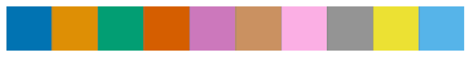

```python
# Set standard styling for visualizations

# writer has slight vision deficiency, these features assist
custom_palette = sns.color_palette('colorblind')
sns.set(rc={'grid.color': 'gray', 'grid.alpha': 0.5})
sns.palplot(custom_palette)

# Paper context selected for readability in turned in .html format,
# but was originally written in noteebook context
sns.set(style='whitegrid', context='paper', palette= custom_palette)
```

```python
# Set standard styling for charts and numeric displays

# Removes the limit for the number of displayed columns
pd.set_option("display.max_columns", None)
pd.set_option('display.width', 100)
# Sets the limit for the number of displayed rows
pd.set_option("display.max_rows", 200)
# setting the precision of floating numbers to 5 decimal points
pd.set_option("display.float_format", lambda x: "%.5f" % x)
```

```python
def print_outliers_info(data, feature):
   """
   Calculates upper outlier analysis information to pair with visualizations

   data: dataframe
   feature: dataframe column
   """
   Q1 = data[feature].quantile(0.25)
   Q3 = data[feature].quantile(0.75)
   IQR = Q3 - Q1
   upper_bound = Q3 + 1.5 * IQR
   max_feat = data[feature].max()

   outliers = data[(data[feature] > upper_bound)][feature].unique()
   outliers_sorted = np.sort(outliers)

   if len(outliers_sorted) > 6:
       outliers_sorted_abbr = np.append(outliers_sorted[:6], "...etc")
   else:
       outliers_sorted_abbr = outliers_sorted

   if len(outliers) > 0:
       outlier_df = pd.DataFrame({
           "IQR": [IQR],
           "Q3": [Q3],
           "Upper Bound": [upper_bound],
           "Max" : [max_feat],
           "#rows > Upper Bound": [len(data[data[feature] > upper_bound])]
       })
       print(f"{feature} Outliers Information:\n")
       formatted_df = outlier_df.to_string(index=False, col_space=15, justify='left') + '\n'
       print(formatted_df)
       print(f"Unique Values Above Upper Bound: {outliers_sorted_abbr}")
```

```python
def histogram_boxplot(data, feature, figsize=(15, 10), kde=False, bins=None):
    """
    Boxplot and histogram combined

    data: dataframe
    feature: dataframe column
    figsize: size of figure (default (15,10))
    kde: whether to show the density curve (default False)
    bins: number of bins for histogram (default None)
    """

    # creating the 2 subplots
    f2, (ax_box2, ax_hist2) = plt.subplots(
        nrows=2,
        sharex=True,
        gridspec_kw={"height_ratios": (0.25, 0.75), "hspace": 0.05, "top": 0.95},
        figsize=figsize,
    )

    # create a title
    f2.suptitle(f"Histogram and Boxplot for {feature}", fontsize=16)

    # boxplot will be created and a square will indicate the mean value of the column
    create_boxplot(data, feature, ax_box2)

    # create histogram, with consideration of bins
    create_histogram(data, feature, ax_hist2, kde, bins)

    # Calculate and print outliers information for the specific feature
    print_outliers_info(data, feature)

def create_boxplot(data, feature, ax_box):
    sns.boxplot(
        data=data,
        x=feature,
        ax=ax_box,
        showmeans=True,
        meanprops={"marker": "s", "markersize": 8, "markerfacecolor": custom_palette[1], "markeredgecolor": "black"},
        medianprops={'linewidth': 4},
        color=custom_palette[2]
    )
    ax_box.set_xlabel("")

def create_histogram(data, feature, ax_hist, kde, bins):
    sns.histplot(
        data=data, x=feature, kde=kde, ax=ax_hist, bins=bins, alpha=0.7
    ) if bins is not None else sns.histplot(
        data=data, x=feature, kde=kde, ax=ax_hist, alpha=0.7
    )
    add_mean_median_to_histogram(data, feature, ax_hist)

def add_mean_median_to_histogram(data, feature, ax_hist):
    ax_hist.axvline(
        data[feature].mean(), color='black', linestyle='-', linewidth=8
    )
    ax_hist.axvline(
        data[feature].mean(), color=custom_palette[1], linestyle='-', linewidth=5, label="Mean"
    )
    ax_hist.axvline(
        data[feature].median(), color='black', linestyle='-', linewidth=5, label="Median"
    )
    ax_hist.legend(loc='upper right')
```

```python
def labeled_barplot(data, feature, perc=False, n=None, rotation=90, sort_index=False):
    """
    Barplot with percentage at the top

    data: dataframe
    feature: dataframe column
    perc: whether to display percentages instead of count (default is False)
    n: displays the top n category levels (default is None, i.e., display all levels)
    sort_index: whether to sort the index (default is False)
    """
    # Check data type of the column
    if data[feature].dtype == 'O':
       print(f"Skipping outlier analysis for {feature} as it contains string values.")
    elif np.issubdtype(data[feature].dtype, np.number):  # Check if dtype is numeric
       # Perform some action for numeric dtype
       print(f"Performing numeric-specific action for {feature}")
       # Calculate and print outliers information for the specific feature
       print_outliers_info(data, feature)
    else:
       print(f"Unsupported dtype for {feature}.")

    # Plot the barplot
    plot_barplot(data, feature, perc, n, rotation, sort_index)

def plot_barplot(data, feature, perc, n, rotation, sort_index):
    total = len(data[feature])  # length of the column
    count = data[feature].nunique()
    if n is None:
        plt.figure(figsize=(count + 2, 6))
    else:
        plt.figure(figsize=(n + 2, 6))

    plt.xticks(rotation=rotation, fontsize=15)

    order = data[feature].value_counts().index[:n]
    if sort_index:
        order = sorted(order)

    ax = create_countplot(data, feature, order)

    for p in ax.patches:
        add_percentage_label(p, total, perc)

    # Add title
    plt.title(f"Barplot for {feature}")

    plt.show()  # show the plot

def create_countplot(data, feature, order):
    return sns.countplot(
        data=data,
        x=feature,
        palette=custom_palette,
        order=order,
    )

def add_percentage_label(p, total, perc):
    if perc:
        label = "{:.1f}%".format(
            100 * p.get_height() / total
        )  # percentage of each class of the category
    else:
        label = p.get_height()  # count of each level of the category

    x = p.get_x() + p.get_width() / 2  # width of the plot
    y = p.get_height()  # height of the plot

    plt.annotate(
        label,
        (x, y),
        ha="center",
        va="center",
        size=12,
        xytext=(0, 5),
        textcoords="offset points",
    )  # annotate the percentage
```

```python
def stacked_barplot(data, predictor, target, rotation=90, sort_columns=True):
    """
    Print the category counts and plot a stacked bar chart

    data: dataframe
    predictor: independent variable
    target: target variable
    rotation: rotation angle for x-axis labels (default is 90)
    sort_columns: whether to sort columns by values in the predictor/x-axis (default is True)
    """
    count = data[predictor].nunique()
    sorter = data[target].value_counts().index[-1]

    # make crosstab showing counts and percents of predictor to target
    tab1 = pd.crosstab(data[predictor], data[target], margins=True, margins_name="Total")
    tab1_percent = pd.crosstab(data[predictor], data[target], margins=True, margins_name="Total", normalize="index") * 100
    tab1_percent_str = tab1_percent.round(2).astype(str)

    # concatenate the count (n) and the %
    tab2 = (pd.concat([tab1, tab1_percent_str], axis=1, keys=['n', '%'])
      .swaplevel(axis=1)
      .sort_index(axis = 1, ascending = True)
    )
    print(tab2)
    print("-" * 120)

    # make stacked barplot
    if sort_columns:
        tab = pd.crosstab(data[predictor], data[target], normalize="index").sort_values(
            by=sorter, ascending=False
        )
    else:
        tab = pd.crosstab(data[predictor], data[target], normalize="index")

    tab.plot(kind="bar", stacked=True, figsize=(count + 5, 5))
    plt.legend(
        loc="lower left", frameon=False,
    )
    plt.legend(loc="upper left", bbox_to_anchor=(1, 1))
    plt.xticks(rotation=rotation, fontsize=15)
    plt.show()
```

```python
### function to plot distributions wrt target
def distribution_plot_wrt_target(data, predictor, target):

    fig, axs = plt.subplots(2, 2, figsize=(12, 10))

    target_uniq = data[target].unique()

    axs[0, 0].set_title("Distribution of target for target=" + str(target_uniq[0]))
    sns.histplot(
        data=data[data[target] == target_uniq[0]],
        x=predictor,
        kde=True,
        ax=axs[0, 0],
        color=custom_palette[2],
        alpha=0.7,
        stat="density",
        line_kws={"color": "black"}
    )

    axs[0, 1].set_title("Distribution of target for target=" + str(target_uniq[1]))
    sns.histplot(
        data=data[data[target] == target_uniq[1]],
        x=predictor,
        kde=True,
        ax=axs[0, 1],
        color=custom_palette[3],
        alpha=0.7,
        stat="density",
        line_kws={"color": "black"}
    )

    axs[1, 0].set_title("Boxplot w.r.t target")
    sns.boxplot(
        data=data,
        x=target,
        y=predictor,
        ax=axs[1, 0]
    )

    axs[1, 1].set_title("Boxplot (without outliers) w.r.t target")
    sns.boxplot(
        data=data,
        x=target,
        y=predictor,
        ax=axs[1, 1],
        showfliers=False,
    )

    plt.tight_layout()
    plt.show()
```

```python
def model_performance_classification_sklearn(model, predictors, target):
    """
    Function to compute different metrics to check classification model performance

    model: classifier
    predictors: independent variables
    target: dependent variable
    """

    # predicting using the independent variables
    pred = model.predict(predictors)

    acc = accuracy_score(target, pred)  # to compute Accuracy
    recall = recall_score(target, pred)  # to compute Recall
    precision = precision_score(target, pred)  # to compute Precision
    f1 = f1_score(target, pred)  # to compute F1-score

    # creating a dataframe of metrics
    df_perf = pd.DataFrame(
        {"Accuracy": acc, "Recall": recall, "Precision": precision, "F1": f1,},
        index=[0],
    )

    return df_perf
```

```python
def make_confusion_matrix(model,X_data_used,y_actual,labels=[1, 0]):
    '''
    model : classifier to predict values of X
    y_actual : ground truth

    '''
    y_predict = model.predict(X_data_used)
    cm=metrics.confusion_matrix( y_actual, y_predict, labels=[0, 1])
    df_cm = pd.DataFrame(cm, index = [i for i in ["Actual - No","Actual - Yes"]],
                  columns = [i for i in ['Predicted - No','Predicted - Yes']])
    group_counts = ["{0:0.0f}".format(value) for value in
                cm.flatten()]
    group_percentages = ["{0:.2%}".format(value) for value in
                         cm.flatten()/np.sum(cm)]
    labels = [f"{v1}\n{v2}" for v1, v2 in
              zip(group_counts,group_percentages)]
    labels = np.asarray(labels).reshape(2,2)
    plt.figure(figsize = (10,7))
    sns.heatmap(df_cm, annot=labels,fmt='')
    plt.ylabel('True label')
    plt.xlabel('Predicted label')
```

## Import Dataset, Overview

### Import Dataset

```python
# read the data
from google.colab import files
import io

try:
    uploaded
except NameError:
    uploaded = files.upload()

visa = pd.read_csv(io.BytesIO(uploaded['EasyVisa.csv']))
```

Upload widget is only available when the cell has been executed in the current browser session. Please rerun this cell to enable.

```
Saving EasyVisa.csv to EasyVisa.csv
```

```python
data = visa.copy() # copying data to another variable to avoid any changes to original data
```

### Data Overview

```python
data.head() #view top 5 rows of the data
```

|  | case_id | continent | education_of_employee | has_job_experience | requires_job_training | no_of_employees | yr_of_estab | region_of_employment | prevailing_wage | unit_of_wage | full_time_position | case_status |
| --- | --- | --- | --- | --- | --- | --- | --- | --- | --- | --- | --- | --- |
| 0 | EZYV01 | Asia | High School | N | N | 14513 | 2007 | West | 592.20290 | Hour | Y | Denied |
| 1 | EZYV02 | Asia | Master's | Y | N | 2412 | 2002 | Northeast | 83425.65000 | Year | Y | Certified |
| 2 | EZYV03 | Asia | Bachelor's | N | Y | 44444 | 2008 | West | 122996.86000 | Year | Y | Denied |
| 3 | EZYV04 | Asia | Bachelor's | N | N | 98 | 1897 | West | 83434.03000 | Year | Y | Denied |
| 4 | EZYV05 | Africa | Master's | Y | N | 1082 | 2005 | South | 149907.39000 | Year | Y | Certified |

```python
data.tail() #view final 5 rows of the data
```

|  | case_id | continent | education_of_employee | has_job_experience | requires_job_training | no_of_employees | yr_of_estab | region_of_employment | prevailing_wage | unit_of_wage | full_time_position | case_status |
| --- | --- | --- | --- | --- | --- | --- | --- | --- | --- | --- | --- | --- |
| 25475 | EZYV25476 | Asia | Bachelor's | Y | Y | 2601 | 2008 | South | 77092.57000 | Year | Y | Certified |
| 25476 | EZYV25477 | Asia | High School | Y | N | 3274 | 2006 | Northeast | 279174.79000 | Year | Y | Certified |
| 25477 | EZYV25478 | Asia | Master's | Y | N | 1121 | 1910 | South | 146298.85000 | Year | N | Certified |
| 25478 | EZYV25479 | Asia | Master's | Y | Y | 1918 | 1887 | West | 86154.77000 | Year | Y | Certified |
| 25479 | EZYV25480 | Asia | Bachelor's | Y | N | 3195 | 1960 | Midwest | 70876.91000 | Year | Y | Certified |

```python
data.shape # view dimensions of the data
```

```
(25480, 12)
```

```python
data.duplicated().sum() # checking for duplicate values
```

```
0
```

No duplicate values so far - but the case_ids do look unique and ordinal. We will need to check that, and possibly look for duplicates again.

```python
data.info() ##  view datatypes for each column, preliminary missing value check
```

```
<class 'pandas.core.frame.DataFrame'>
RangeIndex: 25480 entries, 0 to 25479
Data columns (total 12 columns):
 #   Column                 Non-Null Count  Dtype
---  ------                 --------------  -----
 0   case_id                25480 non-null  object
 1   continent              25480 non-null  object
 2   education_of_employee  25480 non-null  object
 3   has_job_experience     25480 non-null  object
 4   requires_job_training  25480 non-null  object
 5   no_of_employees        25480 non-null  int64
 6   yr_of_estab            25480 non-null  int64
 7   region_of_employment   25480 non-null  object
 8   prevailing_wage        25480 non-null  float64
 9   unit_of_wage           25480 non-null  object
 10  full_time_position     25480 non-null  object
 11  case_status            25480 non-null  object
dtypes: float64(1), int64(2), object(9)
memory usage: 2.3+ MB
```

- Most data is object. Will want to onvert into categorical to make future analysis computationally efficient.
- The only float is the prevailing_wage, and there are two integer values in no_of_employess and yr_of_estab
- Appear to be no missing values, but will need to check the unique values in EDA to ensure there are not placeholders for missing values.

```python
data.describe().T ## describe the numerical data for sanity/cleanliness
```

|  | count | mean | std | min | 25% | 50% | 75% | max |
| --- | --- | --- | --- | --- | --- | --- | --- | --- |
| no_of_employees | 25480.00000 | 5667.04321 | 22877.92885 | -26.00000 | 1022.00000 | 2109.00000 | 3504.00000 | 602069.00000 |
| yr_of_estab | 25480.00000 | 1979.40993 | 42.36693 | 1800.00000 | 1976.00000 | 1997.00000 | 2005.00000 | 2016.00000 |
| prevailing_wage | 25480.00000 | 74455.81459 | 52815.94233 | 2.13670 | 34015.48000 | 70308.21000 | 107735.51250 | 319210.27000 |

- There are some data points with negative employee numbers, that need adresseing
- There is something about the years being treated as numbers that is not intuitive to me. I may add a feature that is "years since founding" relative to the data set date of 2016; but this should no affect the modeling in anyway, more of a personal preference.
- The prevailing_wage column, without the context of the unit, is not easily interpretable. The $2.13 per hour is also not a context I understand; are Visas granted for tip-based jobs like servers? There are also very high paid prevailing wages/jobs that do not seem accurate. They will likely be trimmed in EDA.

### Next steps

1. Check to see if all case_ids are unique - they appear to all be "EZYV" which is our company code followed by an integer that is index +1.
2. Two questions for Subject Matter Expert or other data teammates: Advice on the nature of the error behind the negative number of employees, and advice on the emloyees in the $2.13 range - are these servers? Is this data entry mistake?
3. Convert the object data types into categorical or encode numerically
4. The combination of the prevailing_wage and unit_of_wage leads me to think to transform that data into all the same unit. However, this would require that all roles treat "full time" the same way which may be an innapropriate assumption.

## Data Preprocessing

> 1. Check to see if all case_ids are unique - they appear to all be "EZYV" which is our company code followed by an integer that is index +1.

```python
data['case_id'].nunique() # number of unique value in the case_id column
```

```
25480
```

There are 25,480 rows of data, and each has a unique case_id. Remove this column, then recheck for duplicates:

```python
data = data.drop('case_id', axis=1)
data.duplicated().sum()
```

```
0
```

No duplicates again, great.

> 1. Two questions for Subject Matter Expert or other data teammates: Advice on the nature of the error behind the negative number of employees, and advice on the emloyees in the $2.13 range - are these servers? Is this data entry mistake?
- SME said to treat the number of employees as an absoulte value instead, such that -26 is changed to 26.
- Did not get an answer on the $2.13/hr employee, but this might get treated in outlier work during EDA.

```python
data["no_of_employees"] = data["no_of_employees"].abs() #replace the no_of_employees data with the absolute value of itself
```

> 1. Convert the object data types into categorical or encode numerically

Lets first take a look at the unique values for the object columns -

```python
obj_col = data.select_dtypes(include=['object']).columns
for column in obj_col:
    print(f'Column: {column}')
    print(data[column].value_counts())
    print("\n")
```

```
Column: continent
Asia             16861
Europe            3732
North America     3292
South America      852
Africa             551
Oceania            192
Name: continent, dtype: int64


Column: education_of_employee
Bachelor's     10234
Master's        9634
High School     3420
Doctorate       2192
Name: education_of_employee, dtype: int64


Column: has_job_experience
Y    14802
N    10678
Name: has_job_experience, dtype: int64


Column: requires_job_training
N    22525
Y     2955
Name: requires_job_training, dtype: int64


Column: region_of_employment
Northeast    7195
South        7017
West         6586
Midwest      4307
Island        375
Name: region_of_employment, dtype: int64


Column: unit_of_wage
Year     22962
Hour      2157
Week       272
Month       89
Name: unit_of_wage, dtype: int64


Column: full_time_position
Y    22773
N     2707
Name: full_time_position, dtype: int64


Column: case_status
Certified    17018
Denied        8462
Name: case_status, dtype: int64
```

```python
data.describe(include = ['object']).T # quick table to show modes and number of unique values
```

|  | count | unique | top | freq |
| --- | --- | --- | --- | --- |
| continent | 25480 | 6 | Asia | 16861 |
| education_of_employee | 25480 | 4 | Bachelor's | 10234 |
| has_job_experience | 25480 | 2 | Y | 14802 |
| requires_job_training | 25480 | 2 | N | 22525 |
| region_of_employment | 25480 | 5 | Northeast | 7195 |
| unit_of_wage | 25480 | 4 | Year | 22962 |
| full_time_position | 25480 | 2 | Y | 22773 |
| case_status | 25480 | 2 | Certified | 17018 |

- There do not appear to be any categorical "missing" type values in this data.
- If an there was a "modal applicant" to represent this dataset, they would have the characteristics of being Certified, Asian, holding a Bachelor's degree, having job experience, requiring no job training, and being recruited for a full-time, annual salary position in the Northeast.
- Let convert these object types into categorical and then see if the python category codes line up the way we want; if not we can encode them the way we like later during the second pre-processing.
  - `education_of_employee` encoded as 1-4 from High School to Doctoral
  - `has_job_experice` encoded as 1 for Yes and 0 for No
  - `requires_job_training` endoded as as 1 for Yes and 0 for No
  - `full_time_position` endoded as as 1 for Yes and 0 for No
  - `case_status` endocded as 1 for Certified and 0 for Denied

```python
for column in obj_col:
    data[column] = data[column].astype('category') # change the object columns to category columns

    #goal: print the python category codes for each categorical variable

    #create temporary dataframe to store the category codes
    df_cat_codes = pd.DataFrame() #create temporary dataframe. Since it loops it will rewrite all rows everytime
    df_cat_codes['category'] = data[column] #add the original data column so the strings are visible
    df_cat_codes['code'] = data[column].cat.codes # add the python category codes for each line

    #printing steps
    #remove the duplicates to trim the dataframe to just one copy of each unique category/code
    df_cat_codes = df_cat_codes.drop_duplicates().sort_values(by = ['code'])
    print(f"Column: {column}") # print which column
    print(df_cat_codes) #print the temporary dataframe
    print("\n")  # formatting choice
```

```
Column: continent
          category  code
4           Africa     0
0             Asia     1
9           Europe     2
7    North America     3
241        Oceania     4
121  South America     5


Column: education_of_employee
      category  code
2   Bachelor's     0
9    Doctorate     1
0  High School     2
1     Master's     3


Column: has_job_experience
  category  code
0        N     0
1        Y     1


Column: requires_job_training
  category  code
0        N     0
2        Y     1


Column: region_of_employment
      category  code
105     Island     0
8      Midwest     1
1    Northeast     2
4        South     3
0         West     4


Column: unit_of_wage
    category  code
0       Hour     0
220    Month     1
113     Week     2
1       Year     3


Column: full_time_position
   category  code
21        N     0
0         Y     1


Column: case_status
    category  code
1  Certified     0
0     Denied     1
```

This tells me it is worth the effort to manually encode as part of preprocessing. Waiting until then since priliminaty EDA is easier with the category stings.

> 1. The combination of the prevailing_wage and unit_of_wage leads me to think to transform that data into all the same unit. However, this would require that all roles treat "full time" the same way which may be an innapropriate assumption.
- The vast majority of the data is in the Year unit of wage.
- Lets see how many of those in the monthly, weekly, hourly are full time roles:

```python
data.groupby(['full_time_position', 'unit_of_wage']).size()
```

```
full_time_position  unit_of_wage
N                   Hour               19
                    Month               5
                    Week               10
                    Year             2673
Y                   Hour             2138
                    Month              84
                    Week              262
                    Year            20289
dtype: int64
```

There are only 34 employees that are neither full time nor annual wage workers. These employees constitute 0.1% of the data. I considered three ways to handle this data when changing all wages to an annual estimate.

1. Treat "full_time = N" as exactly half time as an estimate.
2. Remove the 34 employees in the full_time = N and wage =/= Year from the data set
3. Treat the 34 employees as annual for the purposes of the wage estimate.

I opted for option 3 to simplify the treatment. These employees are mathematically treated as full-time while retaining the categorical variable 'N' for full time."

- If we make assumptions that most US non-salaried employees work..
  - 40 hours a week
  - 52 weeks a year (accouting for 2 weeks paid leave a year in the USA for this type of employee)
  - 12 months a year  
    ....then we can convert all to annual wages.
- If these assumptions on converstion are faulty, they represent just under 10% of the data, and the categorical column of `unit of wage` will remain to support model building. The magnitude of the possible impact is noted.

```python
# Create a function to convert wages to the yearly unit
def annualize(row):
    unit = row['unit_of_wage']
    wage = row['prevailing_wage']

    if unit == 'Hour':
        return wage * 40 * 52  # Assuming 40 hours per week and 52 weeks per year
    elif unit == 'Week':
        return wage * 52  # Assuming 52 weeks per year
    elif unit == 'Month':
        return wage * 12  # Assuming 12 months per year
    else:
        return wage  # If already in yearly unit or unknown unit, return as is

# Apply the function to create a new column 'yearly_wage'
data['yearly_wage'] = data.apply(annualize, axis=1)
data = data.drop('prevailing_wage', axis = 1)
```

```python
data.describe().T #check new statistical data
```

|  | count | mean | std | min | 25% | 50% | 75% | max |
| --- | --- | --- | --- | --- | --- | --- | --- | --- |
| no_of_employees | 25480.00000 | 5667.08921 | 22877.91745 | 11.00000 | 1022.00000 | 2109.00000 | 3504.00000 | 602069.00000 |
| yr_of_estab | 25480.00000 | 1979.40993 | 42.36693 | 1800.00000 | 1976.00000 | 1997.00000 | 2005.00000 | 2016.00000 |
| yearly_wage | 25480.00000 | 197391.15526 | 578591.66631 | 100.00000 | 47107.96500 | 82839.46000 | 124825.03500 | 14569149.40000 |

Still have a set of employees whose prevailing wage are both unreasonably low and high. Will do outlier treatment after EDA.

## EDA 1 (data = data)

This is broken into three sections;

- **Leading Questions** provided by the "client"
- **Key Insights** which is a summary of all the EDA from Round 1
- **Appendix** is the bulk of the EDA work done in the project and is located at the end of the notebook. This first round of EDA uses the dataframe "data".

### **Leading Questions**:

> 1. Those with higher education may want to travel abroad for a well-paid job. Does education play a role in Visa certification?

```
case_status           Certified        Denied        Total
                              %      n      %     n      n
education_of_employee
Bachelor's                62.21   6367  37.79  3867  10234
Doctorate                 87.23   1912  12.77   280   2192
High School               34.04   1164  65.96  2256   3420
Master's                  78.63   7575  21.37  2059   9634
Total                     66.79  17018  33.21  8462  25480
------------------------------------------------------------------------------------------------------------------------
```

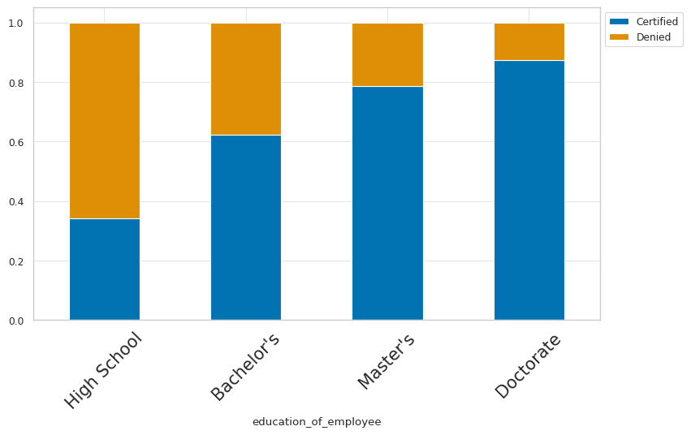

```python
#Bivariate analysis of the relatonship between education and the target Visa Ceritification
stacked_barplot(data, 'education_of_employee', 'case_status',rotation = 45)
```

There appears to be a high correlation between level of education and percent of applicants who are certified. There is a trend in this dataset suggesting that, as the level of education increases, the likelihood of certification also tends to increase.

The entire data set, as a whole, has an certification rate of 67%.

High school and Bacehlor's educated applicants had average certification rates below this overall certification rate, with rates of 34% and 62% respectively.

Master's and Doctorate educated applicates had higher certification rates than the overall certification rate, with rates of 79% and 87% respectively.

> 1. How does the visa status vary across different continents?

```
case_status   Certified        Denied        Total
                      %      n      %     n      n
continent
Africa            72.05    397  27.95   154    551
Asia              65.31  11012  34.69  5849  16861
Europe            79.23   2957  20.77   775   3732
North America     61.88   2037  38.12  1255   3292
Oceania           63.54    122  36.46    70    192
South America     57.86    493  42.14   359    852
Total             66.79  17018  33.21  8462  25480
------------------------------------------------------------------------------------------------------------------------
```

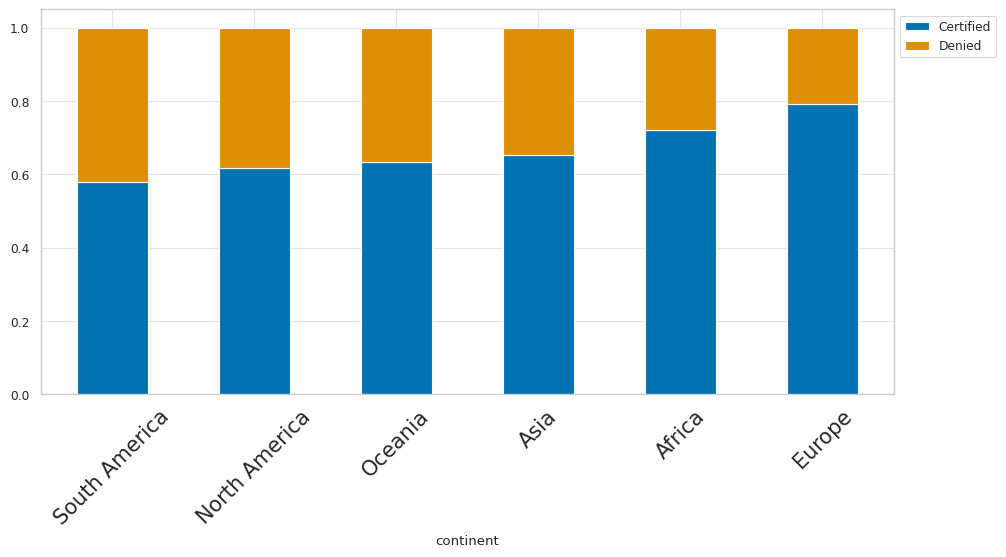

```python
#Bivariate analysis of the relatonship between continent of applicant and the target Visa Ceritification
stacked_barplot(data, 'continent', 'case_status', rotation = 45)
```

> 1. Experienced professionals might look abroad for opportunities to improve their lifestyles and career development. Does work experience influence visa status?

```
case_status        Certified        Denied        Total
                           %      n      %     n      n
has_job_experience
N                      56.13   5994  43.87  4684  10678
Y                      74.48  11024  25.52  3778  14802
Total                  66.79  17018  33.21  8462  25480
------------------------------------------------------------------------------------------------------------------------
```

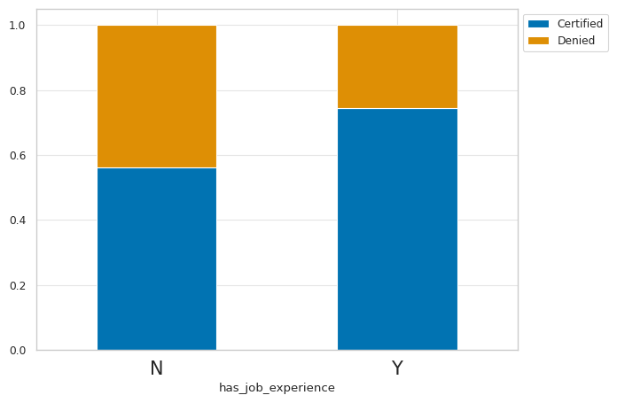

```python
#Bivariate analysis of the relatonship between job experience of applicant and the target Visa Ceritification
stacked_barplot(data, 'has_job_experience', 'case_status', rotation = 0)
```

This data set shows that, for these applicants, those with more job experience had higher slightly higher certification rates.

Across all applicants, the certification rate is 66.79% Applicants without job experience had a rate of 56.13% Applicants with job experience had a rate of 74.48%

> 1. In the United States, employees are paid at different intervals. Which pay unit is most likely to be certified for a visa?

```
case_status  Certified        Denied        Total
                     %      n      %     n      n
unit_of_wage
Hour             34.63    747  65.37  1410   2157
Month             61.8     55   38.2    34     89
Week             62.13    169  37.87   103    272
Year             69.89  16047  30.11  6915  22962
Total            66.79  17018  33.21  8462  25480
------------------------------------------------------------------------------------------------------------------------
```

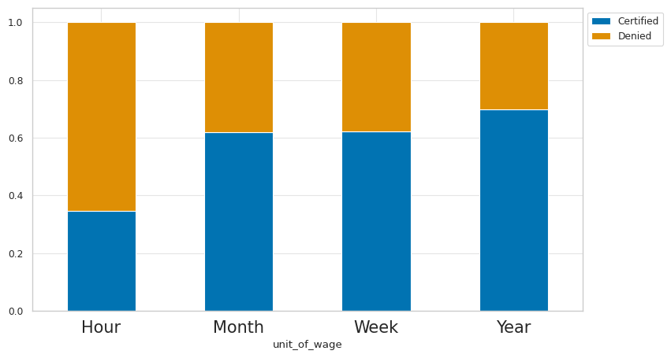

```python
#Bivariate analysis of the relatonship between pay interval of recruited role and the target Visa Ceritification
stacked_barplot(data, 'unit_of_wage', 'case_status', rotation = 0)
```

There appears to a relationship between length of unit of wage and cerification rate - as the unit of time increases, so does the certification rate.

The annual salary applicants represent the vast majority of the data set. The annual salary applicants had also had the highest certification rate with 70%.

Month and Week wage applicants which very near eachother with certification rates of 62% when rounded. These two categories combined represent less of the sample than hourly applicants.

Hourly applicants had the lowest with 35% certification.

> 1. The US government has established a prevailing wage to protect local talent and foreign workers. How does the visa status change with the prevailing wage?

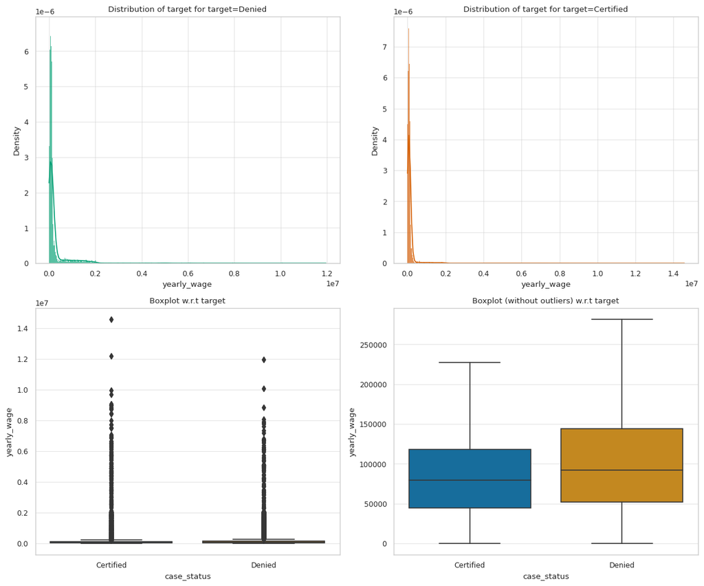

```python
# reminder that feature "yearly_wage" was created earlier to be able to compare with like units
# Bivariate analysis of the relatonship between yearly wage of recruited role and the target Visa Ceritification
distribution_plot_wrt_target(data, "yearly_wage", "case_status")
```

Because the data is incredibly right skewed, lets set an salary cap and then rebuild this visualization. Frist, lets look just at the salary data alone:

```
yearly_wage Outliers Information:

 IQR             Q3              Upper Bound     Max             #rows > Upper Bound
77717.07000     124825.03500    241400.64000    14569149.40000  2387

Unique Values Above Upper Bound: ['241680.07' '241811.15' '241928.36' '242018.37' '242049.6' '242070.4'
 '...etc']
```

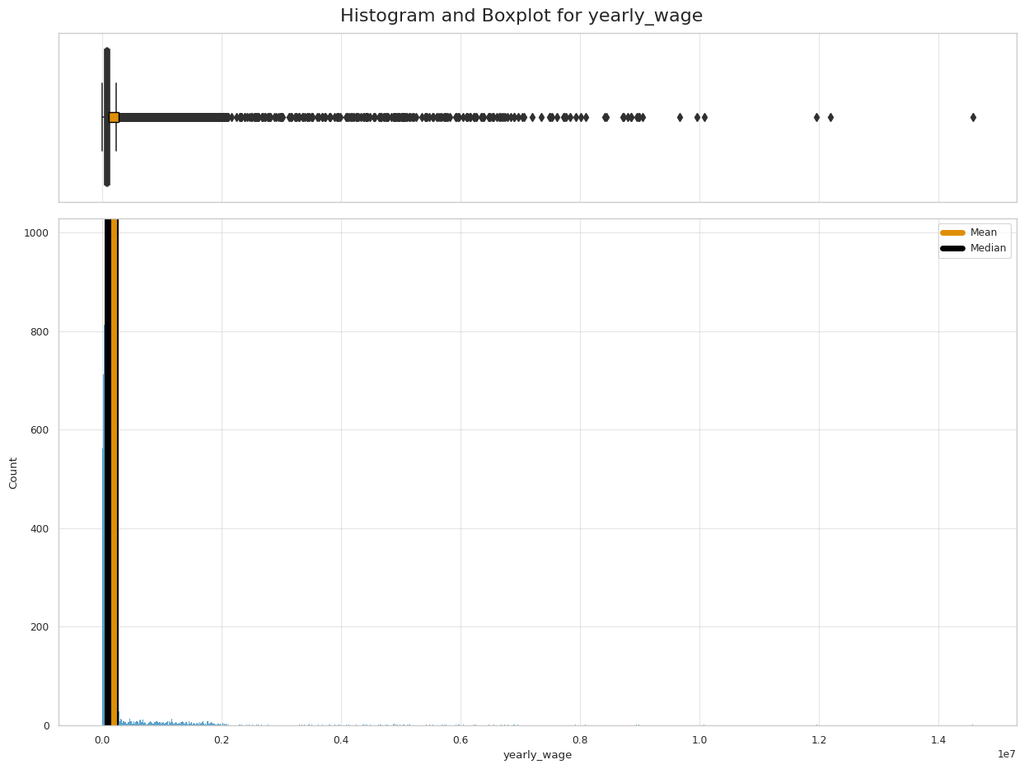

```python
# converting all data from the prevailing wage data to annual salary data with some estimations
histogram_boxplot(data, 'yearly_wage')
```

This is still not the easiest visualization to analyze. So, lets create a new dataframe tha has the salary capped at 250,000 USD (a round value just over the upper bound of Q3 + 1.5*IQR) and use that to visualize this question.

```
yearly_wage Outliers Information:

 IQR             Q3              Upper Bound     Max             #rows > Upper Bound
77717.07000     124825.03500    241400.64000    250000.00000    2387

Unique Values Above Upper Bound: ['241680.07' '241811.15' '241928.36' '242018.37' '242049.6' '242070.4'
 '...etc']
```

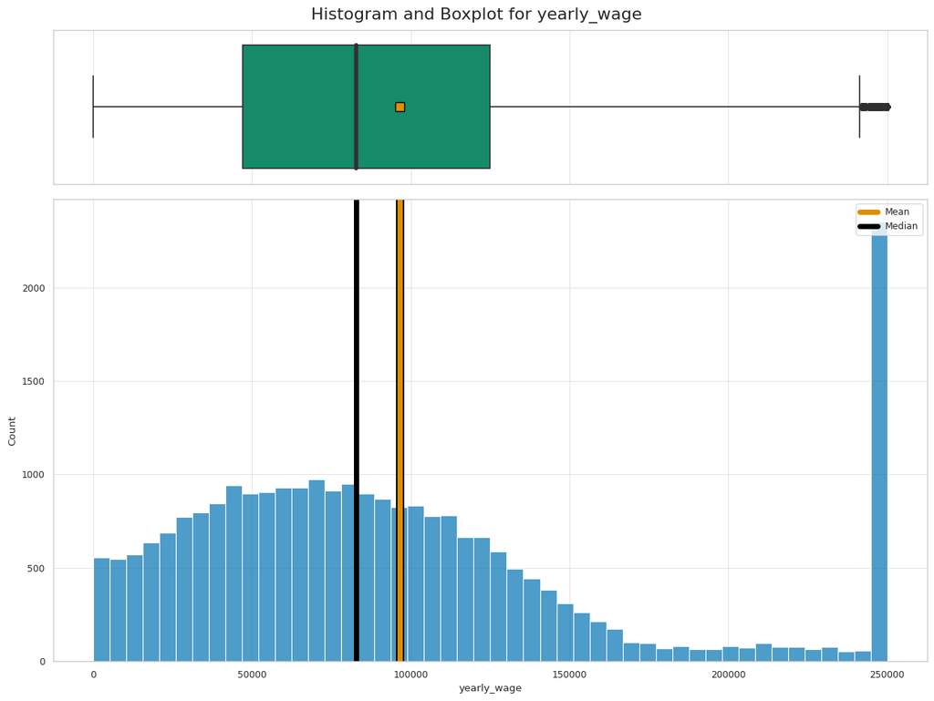

```python
data_salary_cap = data.copy()
data_salary_cap.loc[data_salary_cap["yearly_wage"] >= 250000, "yearly_wage"] = 250000
histogram_boxplot(data_salary_cap, 'yearly_wage')
```

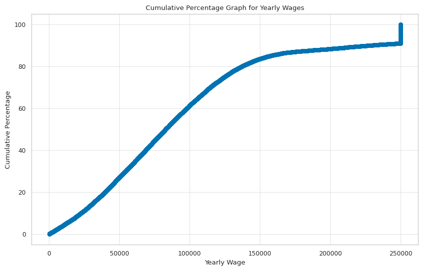

```python
data_salary_cap = data_salary_cap.sort_values(by='yearly_wage')

# Calculate cumulative percentage
cumulative_percentage = np.linspace(0, 100, len(data_salary_cap))

# Plot cumulative percentage graph
plt.figure(figsize=(10, 6))
plt.plot(data_salary_cap['yearly_wage'], cumulative_percentage, marker='o')

# Customize the plot
plt.title('Cumulative Percentage Graph for Yearly Wages')
plt.xlabel('Yearly Wage')
plt.ylabel('Cumulative Percentage')
plt.show()
```

These two visualization show that there is essentially a "outlier bucket" of salaries that are all greater than 250,000 USD. This histogram makes it appear that this "outlier bucket" might dominate the data set, but the Cumulative Distribution and the Box-Plote both show that is not true. The median adjusted annual prevailing income is 82,839 USD and the upper bound is 241,400 USD. Only 2387 applications are above this upper bound, which is 9% of the applications.

Now lets return to visualizing this annual prevailing income to case status:

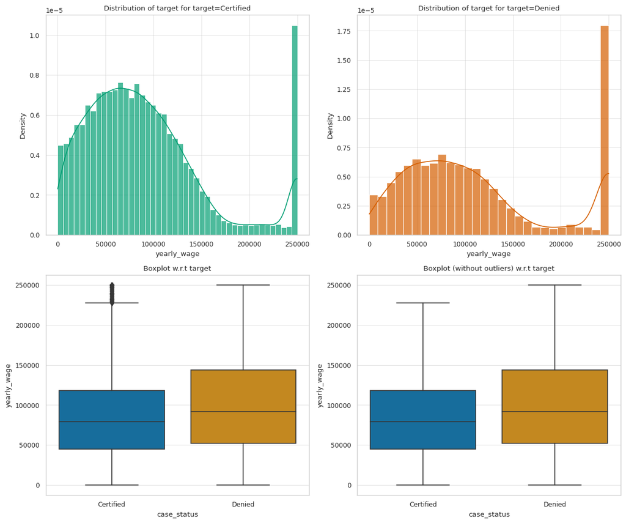

```python
distribution_plot_wrt_target(data_salary_cap, "yearly_wage", "case_status")
```

This is much easier to internalize and/or explain to stakeholders. Here are some key takeaways:

- Applications are Certified and Denied at all levels of Annualized Prevailing Wages. The shapes of the two distributions are very similar.
- A key difference in the shape is that Denials have a larger spread of the IQR of wages than Certification do, including a higher median.
- Further, looking at our "large outliers" grouping of annualized prevailing salaries, there is a higher density of denials for this bracket.
- Surprisingly the small salaries were not flagged as outliers at any point. Given that there are many immigrant owned restaurants in the USA, and the lack of a SME to verify, I will treat those low salaries as valid data points.

### Key Insights

> Numerical Features:
- `no_of_employees` - The data is extremely right skewed. The IQR runs from 1022 to 3504 employees, with 1556 VISA applications are for companies above the upper bound of 7227 employees. THe maximum is 602,069 employees. Outliers were not treated.

## Preparation of Data for Modeling

Summary of steps completed earlier during the Data Preprocessing

- Missing value treatment was not needed for this data.
- Feature engineering - the `yearly_salary` column annualized the data that was present in the `prevailing_wage column`, which was then removed.
- Outlier detection and treatment - Negative `no_of_employees` were changed to their absolute values. No other outliers discoered in EDA required treatment.

Next stepts

- Encoding Categorical Data
- Splitting Data

### Encoding and Data Types

The selected variables for Label Encoding were specifically chosen due to their ordinal nature. Conversely, the decision to use One-Hot Encoding for two variables was based on the absence of a clear ranking between their categories. Notably, the numeric data was left unbinned for this model run, enabling the decision trees to handle the possible creations of bins.

- Label Encoding Steps -
  - `education_of_employee` encoded as 1-4 from High School to Doctoral
  - `has_job_experice` encoded as 1 for Yes and 0 for No
  - `requires_job_training` endoded as as 1 for Yes and 0 for No
  - `unit_of_wage` encoded as 1-4 from Hour to Year
  - `full_time_position` endoded as as 1 for Yes and 0 for No
  - `case_status` endocded as 1 for Certified and 0 for Denied
- One-Hot Encoding -
  - `continent` creating dummy variables. Chosing to specifically drop the Asia category so that we can interpret the coefficients for the other continents in refrence to Asia. The coefficients essentially represent deviations from the largest category.
  - `region_of_employement` creating dummy variables. The largest category is Northeast and specifically dropped.

```python
replaceStruct = {
                "education_of_employee":     {"High School": 1, "Bachelor's": 2 ,"Master's": 3 ,"Doctorate":4},
                "has_job_experience":        {"Y": 1, "N": 0},
                "requires_job_training":     {"Y": 1, "N": 0},
                "unit_of_wage":              {"Hour": 1, "Week": 2 ,"Month": 3 ,"Year":4},
                "full_time_position":        {"Y": 1, "N": 0},
                "case_status":               {"Certified": 1, "Denied": 0}
                    }
oneHotCols=["continent","region_of_employment"]
```

```python
data_prepped = data.copy()
data_prepped = data_prepped.replace(replaceStruct)
data_prepped = pd.get_dummies(data_prepped, columns=oneHotCols)
drop_largest_cat = ["continent_Asia", "region_of_employment_Northeast"] #Instead of dropping the alphabetical first, dropping the largest categories.
data_prepped = data_prepped.drop(columns= drop_largest_cat)
data_prepped.head(10)
```

|  | education_of_employee | has_job_experience | requires_job_training | no_of_employees | yr_of_estab | unit_of_wage | full_time_position | case_status | yearly_wage | continent_Africa | continent_Europe | continent_North America | continent_Oceania | continent_South America | region_of_employment_Island | region_of_employment_Midwest | region_of_employment_South | region_of_employment_West |
| --- | --- | --- | --- | --- | --- | --- | --- | --- | --- | --- | --- | --- | --- | --- | --- | --- | --- | --- |
| 0 | 1 | 0 | 0 | 14513 | 2007 | 1 | 1 | 0 | 1231782.03200 | 0 | 0 | 0 | 0 | 0 | 0 | 0 | 0 | 1 |
| 1 | 3 | 1 | 0 | 2412 | 2002 | 4 | 1 | 1 | 83425.65000 | 0 | 0 | 0 | 0 | 0 | 0 | 0 | 0 | 0 |
| 2 | 2 | 0 | 1 | 44444 | 2008 | 4 | 1 | 0 | 122996.86000 | 0 | 0 | 0 | 0 | 0 | 0 | 0 | 0 | 1 |
| 3 | 2 | 0 | 0 | 98 | 1897 | 4 | 1 | 0 | 83434.03000 | 0 | 0 | 0 | 0 | 0 | 0 | 0 | 0 | 1 |
| 4 | 3 | 1 | 0 | 1082 | 2005 | 4 | 1 | 1 | 149907.39000 | 1 | 0 | 0 | 0 | 0 | 0 | 0 | 1 | 0 |
| 5 | 3 | 1 | 0 | 2339 | 2012 | 4 | 1 | 1 | 78252.14000 | 0 | 0 | 0 | 0 | 0 | 0 | 0 | 1 | 0 |
| 6 | 2 | 0 | 0 | 4985 | 1994 | 4 | 1 | 1 | 53635.39000 | 0 | 0 | 0 | 0 | 0 | 0 | 0 | 1 | 0 |
| 7 | 2 | 1 | 0 | 3035 | 1924 | 1 | 1 | 0 | 869917.98400 | 0 | 0 | 1 | 0 | 0 | 0 | 0 | 0 | 1 |
| 8 | 2 | 0 | 0 | 4810 | 2012 | 4 | 1 | 1 | 74362.19000 | 0 | 0 | 0 | 0 | 0 | 0 | 1 | 0 | 0 |
| 9 | 4 | 1 | 0 | 2251 | 1995 | 4 | 1 | 1 | 67514.76000 | 0 | 1 | 0 | 0 | 0 | 0 | 0 | 1 | 0 |

```python
data_prepped.info()
```

```
<class 'pandas.core.frame.DataFrame'>
RangeIndex: 25480 entries, 0 to 25479
Data columns (total 18 columns):
 #   Column                        Non-Null Count  Dtype
---  ------                        --------------  -----
 0   education_of_employee         25480 non-null  category
 1   has_job_experience            25480 non-null  category
 2   requires_job_training         25480 non-null  category
 3   no_of_employees               25480 non-null  int64
 4   yr_of_estab                   25480 non-null  int64
 5   unit_of_wage                  25480 non-null  category
 6   full_time_position            25480 non-null  category
 7   case_status                   25480 non-null  category
 8   yearly_wage                   25480 non-null  float64
 9   continent_Africa              25480 non-null  uint8
 10  continent_Europe              25480 non-null  uint8
 11  continent_North America       25480 non-null  uint8
 12  continent_Oceania             25480 non-null  uint8
 13  continent_South America       25480 non-null  uint8
 14  region_of_employment_Island   25480 non-null  uint8
 15  region_of_employment_Midwest  25480 non-null  uint8
 16  region_of_employment_South    25480 non-null  uint8
 17  region_of_employment_West     25480 non-null  uint8
dtypes: category(6), float64(1), int64(2), uint8(9)
memory usage: 971.4 KB
```

All variables are accounted for and correctly typed.

### Split the data

```python
X = data_prepped.drop("case_status" , axis=1)
y = data_prepped["case_status"]
```

```python
X_train, X_test, y_train, y_test = train_test_split(X, y, test_size=.30, random_state=1,stratify=y)
```

```python
print("Shape of Training set : ", X_train.shape)
print("Shape of test set : ", X_test.shape)
print("\n")
print("Percentage of classes in training set:")
print(y_train.value_counts(normalize=True))
print("\n")
print("Percentage of classes in test set:")
print(y_test.value_counts(normalize=True))
```

```
Shape of Training set :  (17836, 17)
Shape of test set :  (7644, 17)


Percentage of classes in training set:
1   0.66792
0   0.33208
Name: case_status, dtype: float64


Percentage of classes in test set:
1   0.66784
0   0.33216
Name: case_status, dtype: float64
```

The size of the sets and the percentage of the target variable look appropriate.

## EDA 2 (data = data_prepped)

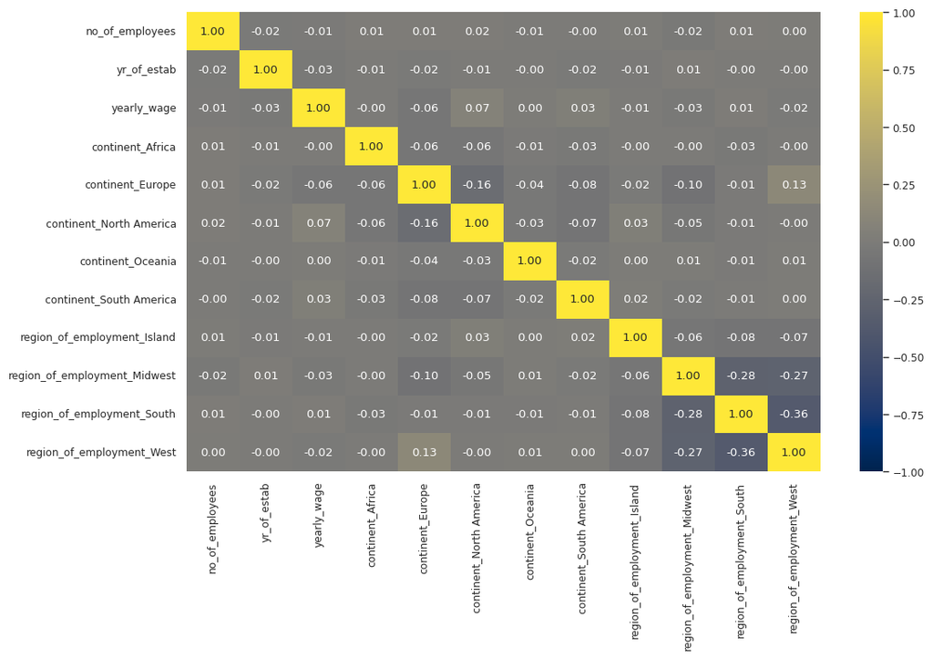

```python
plt.figure(figsize=(12, 7))
sns.heatmap(
    data_prepped.corr(), annot=True, vmin=-1, vmax=1, fmt=".2f", cmap="cividis"
)
plt.show()
```

The reason the rest of the correlations are low even within the encoded categorical variables is because the two largest categories (Asia, Northeat) were removed - leaving behind thoasands of zeros. This leads to a lack of variability and as we can see slighly misleading correlation values.

## Model Building

### Model Evaluation Criteria

Restatment of Purpose: In order to make the visa approval process more effiecient, recommend a suitable profile for applicants for both xases: should be certified and should be denied.

**Error Types**

- Type 1 - 'false positive' - model predicts visa application will get certified, but in reality it should be denied. This results in the visa applicant taking a job that otherwise policy wants a US citizen to fill. This contributes to US unemployment and can contribute to "brain drain".
- Type 2 - 'false negative' - model predicts visa application will be denied, but should be certified. This results in the company struggling to fill the role and grow their business and thus the US economy.

**Model Criterion**

- Both types of errors would result in lower performance metrics for the OFLC
- The `F1 Score` will be the strongest metric for evaluation, minimizing both types of errors equally
- Balanced class weights will help build strong models

My computer began to time out on the AdaBoost Classifier, which means I was unable to continue. Thus, I will backtrack to here and make some adjustment, and the earlier models will be tested on two sets of train&test data.

The two adjustments I want to try are:

1. Eliminate a few features that do not appear to be relevant.
2. Create small random data sets to grid search on, then use those parameters when fitting the the original data to the model.

### Single Decision Tree Model - v1

```python
dtree=DecisionTreeClassifier(random_state=1)
dtree.fit(X_train,y_train)
```

```
DecisionTreeClassifier(random_state=1)
```

```python
dtree_model_train_perf = model_performance_classification_sklearn(dtree, X_train, y_train)
dtree_model_test_perf = model_performance_classification_sklearn(dtree, X_test, y_test)
print("Training performance \n",dtree_model_train_perf)
print("Testing performance \n",dtree_model_test_perf)
```

```
Training performance
    Accuracy  Recall  Precision      F1
0   1.00000 1.00000    1.00000 1.00000
Testing performance
    Accuracy  Recall  Precision      F1
0   0.65869 0.74084    0.74625 0.74354
```

This is very clearly overfitting. Lets add some hyperparameters to help mitigate.

```python
# Choose the type of classifier.
dtree_tuned = DecisionTreeClassifier(random_state=1)

# Grid of parameters to choose from
parameters = {
    'max_depth': list(np.arange(2,20)) + [None],
    'min_samples_leaf': [1, 3, 5, 7, 10],
    'max_leaf_nodes' : [2, 3, 5, 10, 15] + [None],
    'min_impurity_decrease': [0.001, 0.01, 0.1, 0.0]
}

# Type of scoring used to compare parameter combinations
scorer = metrics.make_scorer(metrics.f1_score)

# Run the grid search
grid_obj = GridSearchCV(dtree_tuned, parameters, scoring=scorer,cv=5)
grid_obj = grid_obj.fit(X_train, y_train)

# Set the clf to the best combination of parameters
dtree_tuned = grid_obj.best_estimator_

# Fit the best algorithm to the data.
dtree_tuned.fit(X_train, y_train)
```

```
DecisionTreeClassifier(max_depth=5, max_leaf_nodes=15, random_state=1)
```

```python
dtree_tuned_train = model_performance_classification_sklearn(dtree_tuned, X_train, y_train)
dtree_tuned_test = model_performance_classification_sklearn(dtree_tuned, X_test, y_test)
print("Training performance \n",dtree_tuned_train)
print("Testing performance \n",dtree_tuned_test)
```

```
Training performance
    Accuracy  Recall  Precision      F1
0   0.73761 0.91707    0.74742 0.82360
Testing performance
    Accuracy  Recall  Precision      F1
0   0.73142 0.91714    0.74176 0.82018
```

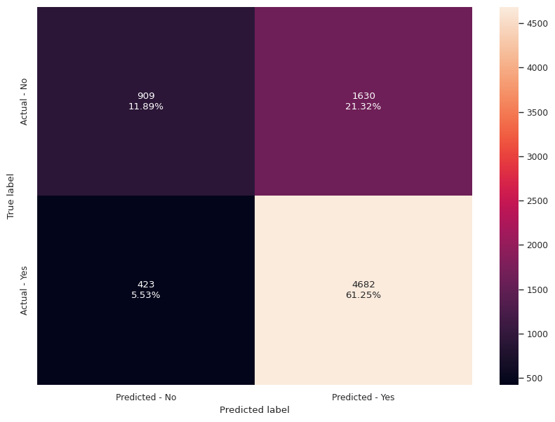

```python
make_confusion_matrix(dtree_tuned, X_test, y_test)
```

```python
# importance of features in the tree building : Gini importance
print(pd.DataFrame(dtree_tuned.feature_importances_, columns = ["Imp"], index = X_train.columns).sort_values(by = 'Imp', ascending = False))
```

```
                                 Imp
education_of_employee        0.49934
has_job_experience           0.21119
unit_of_wage                 0.15054
continent_Europe             0.07090
region_of_employment_Midwest 0.04369
continent_North America      0.01143
continent_South America      0.00721
full_time_position           0.00570
continent_Oceania            0.00000
region_of_employment_South   0.00000
region_of_employment_Island  0.00000
continent_Africa             0.00000
yearly_wage                  0.00000
yr_of_estab                  0.00000
no_of_employees              0.00000
requires_job_training        0.00000
region_of_employment_West    0.00000
```

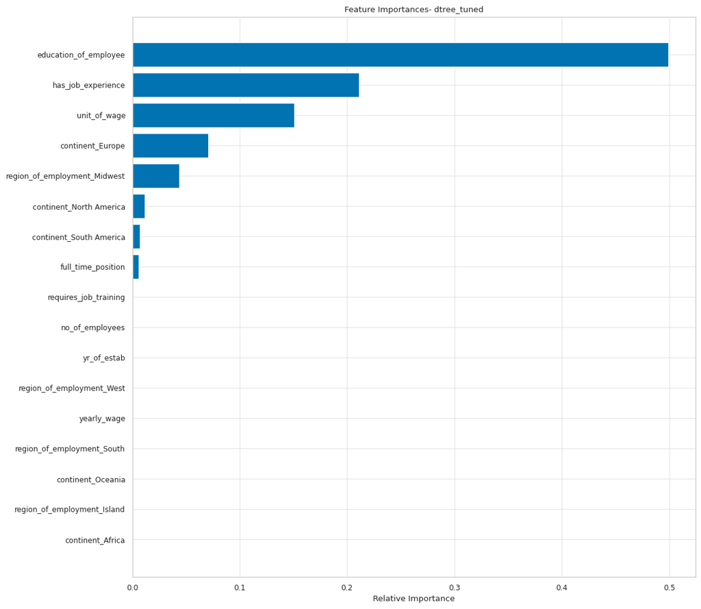

```python
feature_names = X_train.columns
importances = dtree_tuned.feature_importances_
indices = np.argsort(importances)

plt.figure(figsize=(12,12))
plt.title('Feature Importances- dtree_tuned')
plt.barh(range(len(indices)), importances[indices], align='center')
plt.yticks(range(len(indices)), [feature_names[i] for i in indices])
plt.xlabel('Relative Importance')
plt.show()
```

Education and having experience are identified as the two most important features. Let visualize this single Decision Tree as an example for the coming Ensemble Techniques:

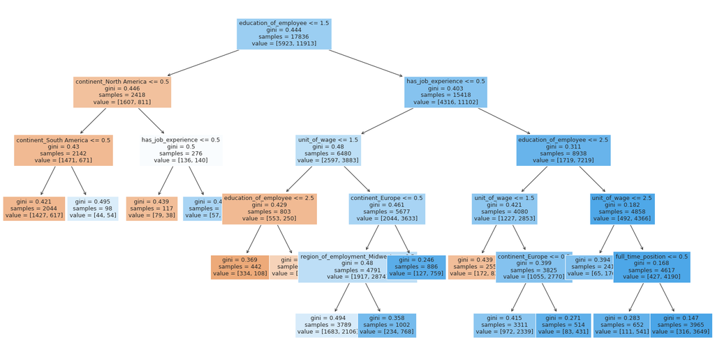

```python
plt.figure(figsize=(20, 10))
out = tree.plot_tree(
    dtree_tuned,
    feature_names=feature_names,
    filled=True,
    fontsize=9,
    node_ids=False,
    class_names=None,
)
plt.show()
```

```python
text_tree = tree.export_text(dtree_tuned, feature_names=feature_names.tolist())
print(text_tree)
```

```
|--- education_of_employee <= 1.50
|   |--- continent_North America <= 0.50
|   |   |--- continent_South America <= 0.50
|   |   |   |--- class: 0
|   |   |--- continent_South America >  0.50
|   |   |   |--- class: 1
|   |--- continent_North America >  0.50
|   |   |--- has_job_experience <= 0.50
|   |   |   |--- class: 0
|   |   |--- has_job_experience >  0.50
|   |   |   |--- class: 1
|--- education_of_employee >  1.50
|   |--- has_job_experience <= 0.50
|   |   |--- unit_of_wage <= 1.50
|   |   |   |--- education_of_employee <= 2.50
|   |   |   |   |--- class: 0
|   |   |   |--- education_of_employee >  2.50
|   |   |   |   |--- class: 0
|   |   |--- unit_of_wage >  1.50
|   |   |   |--- continent_Europe <= 0.50
|   |   |   |   |--- region_of_employment_Midwest <= 0.50
|   |   |   |   |   |--- class: 1
|   |   |   |   |--- region_of_employment_Midwest >  0.50
|   |   |   |   |   |--- class: 1
|   |   |   |--- continent_Europe >  0.50
|   |   |   |   |--- class: 1
|   |--- has_job_experience >  0.50
|   |   |--- education_of_employee <= 2.50
|   |   |   |--- unit_of_wage <= 1.50
|   |   |   |   |--- class: 0
|   |   |   |--- unit_of_wage >  1.50
|   |   |   |   |--- continent_Europe <= 0.50
|   |   |   |   |   |--- class: 1
|   |   |   |   |--- continent_Europe >  0.50
|   |   |   |   |   |--- class: 1
|   |   |--- education_of_employee >  2.50
|   |   |   |--- unit_of_wage <= 2.50
|   |   |   |   |--- class: 1
|   |   |   |--- unit_of_wage >  2.50
|   |   |   |   |--- full_time_position <= 0.50
|   |   |   |   |   |--- class: 1
|   |   |   |   |--- full_time_position >  0.50
|   |   |   |   |   |--- class: 1
```

### Iterate through Preparation of Data for Modeling

My computer began to time out on the AdaBoost Classifier, which means I was unable to continue. Thus, I will backtrack to here and make some adjustments. Since I reference the original Decision Tree Model for its relevancy data, I will make a second version after this data preparation.

The two adjustments I want to try are:

1. Eliminate a few features that do not appear to be relevant.
2. Create small random data sets to grid search on, then use those parameters when fitting the the original data to the model.

**Step 1: Eliminate a few features.**

During the EDA we saw that many of the features were equally represented in the data set. Further, at the point I was tuning the AdaBoost model, the Single Decision Tree still had the largest F1 value. The results of that model produce a relative importance list. Here is a re-print of those

```python
# importance of features in the tree building : Gini importance
print(pd.DataFrame(dtree_tuned.feature_importances_, columns = ["Imp"], index = X_train.columns).sort_values(by = 'Imp', ascending = False))
```

```
                                 Imp
education_of_employee        0.49934
has_job_experience           0.21119
unit_of_wage                 0.15054
continent_Europe             0.07090
region_of_employment_Midwest 0.04369
continent_North America      0.01143
continent_South America      0.00721
full_time_position           0.00570
continent_Oceania            0.00000
region_of_employment_South   0.00000
region_of_employment_Island  0.00000
continent_Africa             0.00000
yearly_wage                  0.00000
yr_of_estab                  0.00000
no_of_employees              0.00000
requires_job_training        0.00000
region_of_employment_West    0.00000
```

The features I want to remove are ones that I know from EDA have very little variation, ones that I see have a small relative importance, while also balancing knowledge that some of these data points are have low representation. This is to avoid any kind of Euro-Asian supremacy in the model

Features to be removed for the new dataframe are:

- requires_job_training
- yr_of_estab
- full_time_position
- no_of_employees

```python
data_reduced = data_prepped.copy()
data_reduced.drop(columns=['requires_job_training','yr_of_estab','full_time_position','no_of_employees'], inplace = True)

data_reduced.info()
```

```
<class 'pandas.core.frame.DataFrame'>
RangeIndex: 25480 entries, 0 to 25479
Data columns (total 14 columns):
 #   Column                        Non-Null Count  Dtype
---  ------                        --------------  -----
 0   education_of_employee         25480 non-null  category
 1   has_job_experience            25480 non-null  category
 2   unit_of_wage                  25480 non-null  category
 3   case_status                   25480 non-null  category
 4   yearly_wage                   25480 non-null  float64
 5   continent_Africa              25480 non-null  uint8
 6   continent_Europe              25480 non-null  uint8
 7   continent_North America       25480 non-null  uint8
 8   continent_Oceania             25480 non-null  uint8
 9   continent_South America       25480 non-null  uint8
 10  region_of_employment_Island   25480 non-null  uint8
 11  region_of_employment_Midwest  25480 non-null  uint8
 12  region_of_employment_South    25480 non-null  uint8
 13  region_of_employment_West     25480 non-null  uint8
dtypes: category(4), float64(1), uint8(9)
memory usage: 523.3 KB
```

```python
X_red = data_reduced.drop("case_status" , axis=1)
y_red = data_reduced["case_status"]
```

```python
X_train_red, X_test_red, y_train_red, y_test_red = train_test_split(X_red, y_red, test_size=.30, random_state=1,stratify=y)
```

```python
print("Shape of Training set : ", X_train_red.shape)
print("Shape of test set : ", X_test_red.shape)
print("\n")
print("Percentage of classes in training set:")
print(y_train_red.value_counts(normalize=True))
print("\n")
print("Percentage of classes in test set:")
print(y_test_red.value_counts(normalize=True))
```

```
Shape of Training set :  (17836, 13)
Shape of test set :  (7644, 13)


Percentage of classes in training set:
1   0.66792
0   0.33208
Name: case_status, dtype: float64


Percentage of classes in test set:
1   0.66784
0   0.33216
Name: case_status, dtype: float64
```

Great - now I have less features to consider. My next step is to create a smaller random sample from these this to test my hyperparametrs on.

```python
# pulling 10% sample from the reduced feature dataframe

X_sample = X_train_red.sample(frac = 0.1, random_state = 1)
y_sample = y_train_red.sample(frac = 0.1, random_state = 1)
```

```python
# check the split:
print("Shape of 10% sample set : ", X_sample.shape)
print("\n")
print("Percentage of classes in training set:")
print(y_sample.value_counts(normalize=True))
```

```
Shape of 10% sample set :  (1784, 13)


Percentage of classes in training set:
1   0.67321
0   0.32679
Name: case_status, dtype: float64
```

### **Moving Forward**

- The reduced data `X_train_red` & `y_train_red` will be used to fit the models and measure performance.
- Starting at AdaBoost forward, the 10% sample data `X_sample` and `y_sample` will be used in fitting the slower GridSearchs.

### Single Decision Tree Model - v2

In order to consistently be able to assess performance across models, the original Decision Tree will be done on the reduced (`red`) data sets. This also allows to see what affect the reduction has on the data.

```python
dtree_red=DecisionTreeClassifier(random_state=1)
dtree_red.fit(X_train_red,y_train_red)
```

```
DecisionTreeClassifier(random_state=1)
```

```python
dtree_red_train = model_performance_classification_sklearn(dtree_red, X_train_red, y_train_red)
dtree_red_test = model_performance_classification_sklearn(dtree_red, X_test_red, y_test_red)
print("Training performance \n",dtree_red_train)
print("Testing performance \n",dtree_red_test)
```

```
Training performance
    Accuracy  Recall  Precision      F1
0   1.00000 1.00000    1.00000 1.00000
Testing performance
    Accuracy  Recall  Precision      F1
0   0.65084 0.73928    0.73826 0.73877
```

So far, comporable results to the original Decision Tree. That is a good sign that we havent oversimplified the data set in the name of processing speed.

```python
# Choose the type of classifier.
dtree_red_tuned = DecisionTreeClassifier(random_state=1)

# Grid of parameters to choose from
parameters = {
    'max_depth': [3,4,5,10],
    'min_samples_leaf': [3, 5, 7],
    'max_leaf_nodes' : [2, 3, 5],
    'min_impurity_decrease': [0.0001, 0.001]
}

# Type of scoring used to compare parameter combinations
scorer = metrics.make_scorer(metrics.f1_score)

# Run the grid search
grid_obj = GridSearchCV(dtree_red_tuned, parameters, scoring=scorer,cv=5)
grid_obj = grid_obj.fit(X_train_red, y_train_red)

# Set the clf to the best combination of parameters
dtree_red_tuned = grid_obj.best_estimator_

# Fit the best algorithm to the data.
dtree_red_tuned.fit(X_train_red, y_train_red)
```

```
DecisionTreeClassifier(max_depth=3, max_leaf_nodes=5,
                       min_impurity_decrease=0.0001, min_samples_leaf=3,
                       random_state=1)
```

```python
dtree_red_tuned_train = model_performance_classification_sklearn(dtree_red_tuned, X_train_red, y_train_red)
dtree_red_tuned_test = model_performance_classification_sklearn(dtree_red_tuned, X_test_red, y_test_red)
print("Training performance \n",dtree_red_tuned_train)
print("Testing performance \n",dtree_red_tuned_test)
```

```
Training performance
    Accuracy  Recall  Precision      F1
0   0.72954 0.91094    0.74252 0.81815
Testing performance
    Accuracy  Recall  Precision      F1
0   0.72331 0.91126    0.73678 0.81478
```

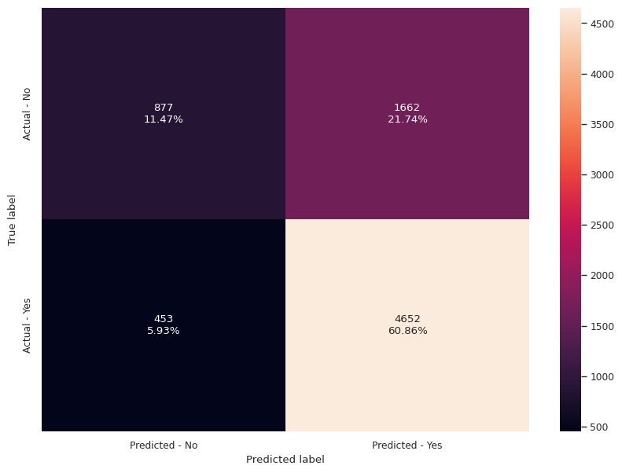

```python
make_confusion_matrix(dtree_red_tuned, X_test_red, y_test_red)
```

The slightly lower F1 score for the dtree_red_tuned can be seen in the Actual-Yes values; this model is getting more False Negatives and less True Positives.

Lets check on the feature importance again:

```python
# importance of features in the tree building : Gini importance
print(pd.DataFrame(dtree_red_tuned.feature_importances_, columns = ["Imp"], index = X_train_red.columns).sort_values(by = 'Imp', ascending = False))
```

```
                                 Imp
education_of_employee        0.62432
has_job_experience           0.25636
unit_of_wage                 0.11932
yearly_wage                  0.00000
continent_Africa             0.00000
continent_Europe             0.00000
continent_North America      0.00000
continent_Oceania            0.00000
continent_South America      0.00000
region_of_employment_Island  0.00000
region_of_employment_Midwest 0.00000
region_of_employment_South   0.00000
region_of_employment_West    0.00000
```

It seems the data has essentially collapsed to those three features at this point. Education, job experience, and unit of wage. Lets visualize this smaller Tree.

[figure not shown]

```python
plt.figure(figsize=(20, 10))
out = tree.plot_tree(
    dtree_red_tuned,
    feature_names=feature_names,
    filled=True,
    fontsize=9,
    node_ids=False,
    class_names=None,
)
plt.show()
```

This is a very clear, easy to understand tree.

### Bagging Classifier

```python
#base_estimator for bagging classifier is a decision tree by default
bagging_estimator=BaggingClassifier(random_state=1)
bagging_estimator.fit(X_train_red,y_train_red)
```

```
BaggingClassifier(random_state=1)
```

```python
bagging_estimator_train = model_performance_classification_sklearn(bagging_estimator, X_train_red, y_train_red)
bagging_estimator_test = model_performance_classification_sklearn(bagging_estimator, X_test_red, y_test_red)
print("Training performance \n",bagging_estimator_train)
print("Testing performance \n",bagging_estimator_test)
```

```
Training performance
    Accuracy  Recall  Precision      F1
0   0.97230 0.97356    0.98480 0.97915
Testing performance
    Accuracy  Recall  Precision      F1
0   0.66837 0.75083    0.75216 0.75149
```

This priliminary is overfitting on the train data. Lets try to tune:

```python
# Choose the type of classifier.
bagging_tuned = BaggingClassifier(random_state=1)

# Grid of parameters to choose from
## add from article
parameters = {
    'max_samples': [0.7,0.8,0.9,1],
    'max_features': [0.7,0.8,0.9,1],
    'n_estimators' : [90,110,10],
}

# Type of scoring used to compare parameter combinations
acc_scorer = metrics.make_scorer(metrics.f1_score)

# Run the grid search
grid_obj = GridSearchCV(bagging_tuned, parameters, scoring=acc_scorer,cv=5)
grid_obj = grid_obj.fit(X_train_red, y_train_red)

# Set the clf to the best combination of parameters
bagging_tuned = grid_obj.best_estimator_

# Fit the best algorithm to the data.
bagging_tuned.fit(X_train_red, y_train_red)
```

```
BaggingClassifier(max_features=0.7, max_samples=0.7, n_estimators=110,
                  random_state=1)
```

```python
bagging_tuned_train = model_performance_classification_sklearn(bagging_tuned, X_train_red, y_train_red)
bagging_tuned_test = model_performance_classification_sklearn(bagging_tuned, X_test_red, y_test_red)
print("Training performance \n",bagging_tuned_train)
print("Testing performance \n",bagging_tuned_test)
```

```
Training performance
    Accuracy  Recall  Precision      F1
0   0.93765 0.99496    0.91848 0.95519
Testing performance
    Accuracy  Recall  Precision      F1
0   0.71206 0.88110    0.73835 0.80343
```

Still pretty seriously overfitting on the training data here. Lets see what the confusion matrix looks like;

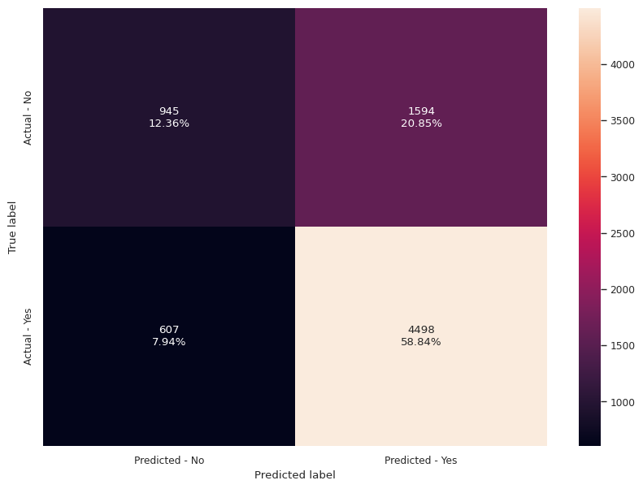

```python
make_confusion_matrix(bagging_tuned,X_test_red, y_test_red)
```

This Tuned Bagging Model is still seeing a very large number of False Positives, and the hyperparameters still didn't not tune this model above the performance of the Single Decision Tree Model on this reduced test data.

### Random Forest Model

```python
rf_estimator=RandomForestClassifier(random_state=1)
rf_estimator.fit(X_train_red,y_train_red)
```

```
RandomForestClassifier(random_state=1)
```

```python
rf_estimator_train = model_performance_classification_sklearn(rf_estimator, X_train_red, y_train_red)
rf_estimator_test = model_performance_classification_sklearn(rf_estimator, X_test_red, y_test_red)
print("Training performance \n",rf_estimator_train)
print("Testing performance \n",rf_estimator_test)
```

```
Training performance
    Accuracy  Recall  Precision      F1
0   0.99978 0.99992    0.99975 0.99983
Testing performance
    Accuracy  Recall  Precision      F1
0   0.66313 0.75436    0.74459 0.74944
```

Again with high overfitting, which can be reduced with tuning; this will be the last model that uses the non-sample data set for the grid-search.

```python
# Choose the type of classifier.
rf_tuned = RandomForestClassifier(random_state=1, oob_score=True, bootstrap=True)

# Grid of parameters to choose from
parameters = {
    'max_depth':[1,3,4,5,10],
    'max_features': ['sqrt','log2'],
    'n_estimators': [20,40,60,80]
}

# Type of scoring used to compare parameter combinations
scorer = metrics.make_scorer(metrics.f1_score)

# Run the grid search
grid_obj = GridSearchCV(rf_tuned, parameters, scoring=scorer,cv=5)
grid_obj = grid_obj.fit(X_train_red, y_train_red)

# Set the clf to the best combination of parameters
rf_tuned = grid_obj.best_estimator_

# Fit the best algorithm to the data.
rf_tuned.fit(X_train_red, y_train_red)
```

```
RandomForestClassifier(max_depth=5, n_estimators=80, oob_score=True,
                       random_state=1)
```

```python
rf_tuned_train = model_performance_classification_sklearn(rf_tuned, X_train_red, y_train_red)
rf_tuned_test = model_performance_classification_sklearn(rf_tuned, X_test_red, y_test_red)
print("Training performance \n",rf_tuned_train)
print("Testing performance \n",rf_tuned_test)
```

```
Training performance
    Accuracy  Recall  Precision      F1
0   0.73268 0.92991    0.73799 0.82291
Testing performance
    Accuracy  Recall  Precision      F1
0   0.72423 0.93164    0.73001 0.81859
```

This is a solid result. Still not see testing F1 performance as high as the dtree_tuned model, but this has better balance with the training data.

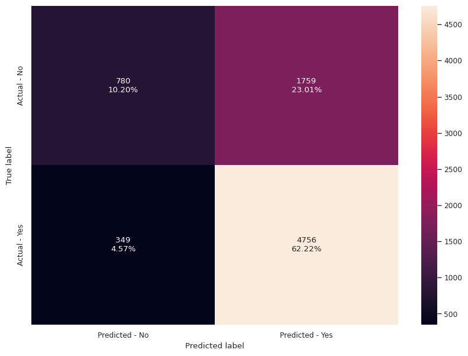

```python
make_confusion_matrix(rf_tuned, X_test_red, y_test_red)
```

Tuning was effective in dramatically reducin the overfitting of the model on the train data. Our new F1 high score is 0.81859 for the Tuned Random Forest. However, the slight improvement over the Tuned Bagging Model comes with a notable change: the Tuned Random Forest predict more Yes conditions; meaning there are both True Positives and False Positives; Precision is down and Recall is up.

### AdaBoost Classifier

My session was consistently timing out on the grid_search, so this will start the models that GridSearch with the sample instead.

```python
ab_classifier = AdaBoostClassifier(random_state=1)
ab_classifier.fit(X_train_red,y_train_red)
```

```
AdaBoostClassifier(random_state=1)
```

```python
ab_classifier_train = model_performance_classification_sklearn(ab_classifier, X_train_red, y_train_red)
ab_classifier_test = model_performance_classification_sklearn(ab_classifier, X_test_red, y_test_red)
print("Training performance \n",ab_classifier_train)
print("Testing performance \n",ab_classifier_test)
```

```
Training performance
    Accuracy  Recall  Precision      F1
0   0.73755 0.88517    0.76093 0.81836
Testing performance
    Accuracy  Recall  Precision      F1
0   0.73509 0.88423    0.75891 0.81679
```

Excellent! With a focuson correcting mistakes of previus learners, we see less overfitting in our initial fit. Lets tune this to see if we can get further improvement.

```python
# Choose the type of classifier.
abc_tuned = AdaBoostClassifier(random_state=1)

# Grid of parameters to choose from
parameters = {
    "base_estimator":[
        DecisionTreeClassifier(max_depth=1, random_state=1),
        DecisionTreeClassifier(max_depth=2, random_state=1),
        DecisionTreeClassifier(max_depth=3, random_state=1)],
    "n_estimators": np.arange(20,110,10),
    "learning_rate": np.arange(0.1,2,0.1)
}

# Type of scoring used to compare parameter combinations
acc_scorer = metrics.make_scorer(metrics.f1_score)

# Run the grid search on the SAMPLE data
grid_obj = GridSearchCV(abc_tuned, parameters, scoring=acc_scorer,cv=5)
grid_obj = grid_obj.fit(X_sample, y_sample)

# Set the clf to the best combination of parameters
abc_tuned = grid_obj.best_estimator_

# Fit the best algorithm to the REDUCED data.
abc_tuned.fit(X_train_red, y_train_red)
```

```
AdaBoostClassifier(base_estimator=DecisionTreeClassifier(max_depth=1,
                                                         random_state=1),
                   learning_rate=0.2, n_estimators=80, random_state=1)
```

```python
abc_tuned_train = model_performance_classification_sklearn(abc_tuned, X_train_red, y_train_red)
abc_tuned_test = model_performance_classification_sklearn(abc_tuned, X_test_red, y_test_red)
print("Training performance \n",abc_tuned_train)
print("Testing performance \n",abc_tuned_test)
```

```
Training performance
    Accuracy  Recall  Precision      F1
0   0.73682 0.88492    0.76033 0.81791
Testing performance
    Accuracy  Recall  Precision      F1
0   0.73469 0.88482    0.75827 0.81667
```

We seem to be hovering around an F1 = 0.82 in all models. Looking forward to stacking.

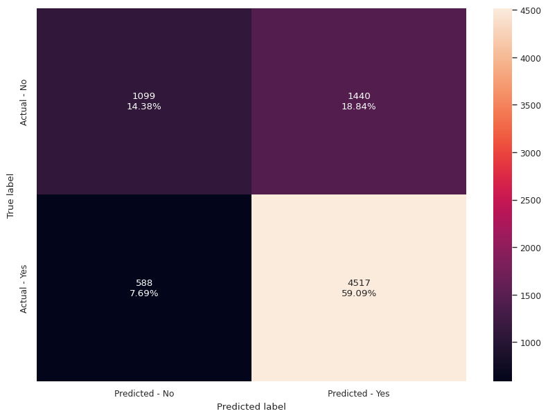

```python
make_confusion_matrix(abc_tuned, X_test_red, y_test_red)
```

This model is reducing the False Positives, but we have yet to outperform the Single Decision Tree Model in False Negatives.

### Gradient Boosting Classifier

```python
gb_classifier = GradientBoostingClassifier(random_state=1)
gb_classifier.fit(X_train_red,y_train_red)
```

```
GradientBoostingClassifier(random_state=1)
```

```python
gb_classifier_train = model_performance_classification_sklearn(gb_classifier, X_train_red, y_train_red)
gb_classifier_test = model_performance_classification_sklearn(gb_classifier, X_test_red, y_test_red)
print("Training performance \n",gb_classifier_train)
print("Testing performance \n",gb_classifier_test)
```

```
Training performance
    Accuracy  Recall  Precision      F1
0   0.75449 0.87333    0.78379 0.82614
Testing performance
    Accuracy  Recall  Precision      F1
0   0.74516 0.86993    0.77572 0.82013
```

This is the highest test F1 since the original dtree_tuned on the full feature set.

Hyperparameter Training -

```python
# Choose the type of classifier.
gbc_tuned = GradientBoostingClassifier(
    init=AdaBoostClassifier(random_state=1), random_state=1 #Adaboost classifier
)

# Grid of parameters to choose from
parameters = {
    "n_estimators": np.arange(20, 200,20),
    "subsample": [0.9, 1],
    "max_features": [0.8, 0.9],
    "learning_rate": np.arange(0.1, 0.21, 0.1),
}

# Type of scoring used to compare parameter combinations
scorer = metrics.make_scorer(metrics.f1_score)

# Run the grid search
grid_obj = GridSearchCV(gbc_tuned, parameters, scoring=scorer,cv=5)
grid_obj = grid_obj.fit(X_sample, y_sample)

# Set the clf to the best combination of parameters
gbc_tuned = grid_obj.best_estimator_

# Fit the best algorithm to the data.
gbc_tuned.fit(X_train_red, y_train_red)
```

```
GradientBoostingClassifier(init=AdaBoostClassifier(random_state=1),
                           max_features=0.8, n_estimators=20, random_state=1,
                           subsample=1)
```

```python
gbc_tuned_train = model_performance_classification_sklearn(gbc_tuned, X_train_red, y_train_red)
gbc_tuned_test = model_performance_classification_sklearn(gbc_tuned, X_test_red, y_test_red)
print("Training performance \n",gbc_tuned_train)
print("Testing performance \n",gbc_tuned_test)
```

```
Training performance
    Accuracy  Recall  Precision      F1
0   0.73739 0.91320    0.74878 0.82286
Testing performance
    Accuracy  Recall  Precision      F1
0   0.72894 0.91185    0.74160 0.81796
```

Cant' find a set of hyperparameters that produces a higher F1 on the test data than the original.

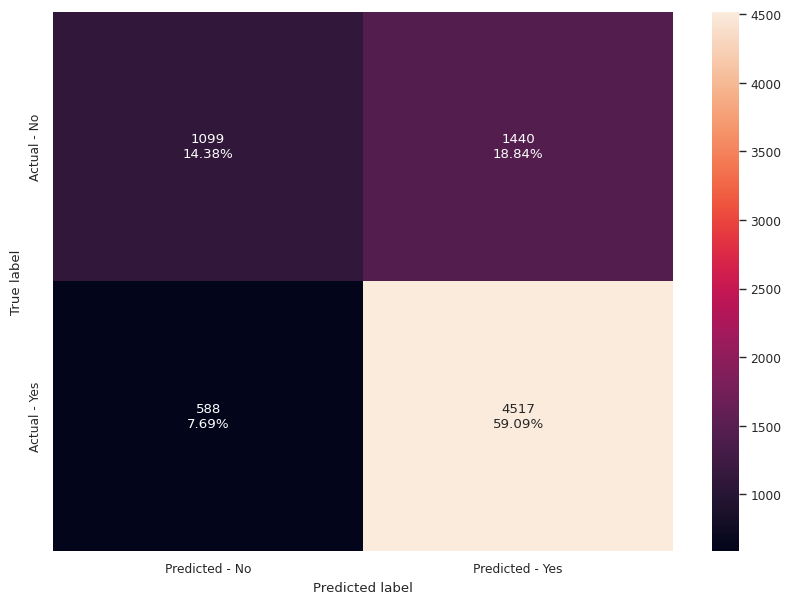

```python
make_confusion_matrix(abc_tuned, X_test_red, y_test_red)
```

### XGBoost Classifier

```python
# the development of this code came from endless error code reading
# I learned about cat.codes
# basically what this is doing is switching my label encoding from the model prep stage
# and restoring the data as python's natural cat codes

X_train_red_encoded = X_train_red.copy()
X_train_red_encoded['education_of_employee'] = X_train_red_encoded['education_of_employee'].cat.codes
X_train_red_encoded['has_job_experience'] = X_train_red_encoded['has_job_experience'].cat.codes
X_train_red_encoded['unit_of_wage'] = X_train_red_encoded['unit_of_wage'].cat.codes

xgb_classifier = XGBClassifier(random_state=1, eval_metric='logloss')
xgb_classifier.fit(X_train_red_encoded, y_train_red)
```

```
XGBClassifier(base_score=None, booster=None, callbacks=None,
              colsample_bylevel=None, colsample_bynode=None,
              colsample_bytree=None, device=None, early_stopping_rounds=None,
              enable_categorical=False, eval_metric='logloss',
              feature_types=None, gamma=None, grow_policy=None,
              importance_type=None, interaction_constraints=None,
              learning_rate=None, max_bin=None, max_cat_threshold=None,
              max_cat_to_onehot=None, max_delta_step=None, max_depth=None,
              max_leaves=None, min_child_weight=None, missing=nan,
              monotone_constraints=None, multi_strategy=None, n_estimators=None,
              n_jobs=None, num_parallel_tree=None, random_state=1, ...)
```

```python
# Now we need to do the same data prep for the X_test_red and the X_sample

X_test_red_encoded = X_train_red.copy()
X_test_red_encoded['education_of_employee'] = X_test_red_encoded['education_of_employee'].cat.codes
X_test_red_encoded['has_job_experience'] = X_test_red_encoded['has_job_experience'].cat.codes
X_test_red_encoded['unit_of_wage'] = X_test_red_encoded['unit_of_wage'].cat.codes

X_sample_encoded = X_sample.copy()
X_sample_encoded['education_of_employee'] = X_sample_encoded['education_of_employee'].cat.codes
X_sample_encoded['has_job_experience'] = X_sample_encoded['has_job_experience'].cat.codes
X_sample_encoded['unit_of_wage'] = X_sample_encoded['unit_of_wage'].cat.codes
```

```python
xgb_classifier_train = model_performance_classification_sklearn(xgb_classifier, X_train_red_encoded, y_train_red)
xgb_classifier_test = model_performance_classification_sklearn(xgb_classifier, X_test_red, y_test_red)
print("Training performance \n",xgb_classifier_train)
print("Testing performance \n",xgb_classifier_test)
```

```
Training performance
    Accuracy  Recall  Precision      F1
0   0.79115 0.89230    0.81319 0.85091
Testing performance
    Accuracy  Recall  Precision      F1
0   0.72894 0.84936    0.76893 0.80715
```

```python
# Choose the type of classifier.
xgb_tuned = XGBClassifier(random_state=1, eval_metric="logloss")

# Grid of parameters to choose from
parameters = {
    "n_estimators": np.arange(150, 250, 50),
    "scale_pos_weight": [1, 2],
    "subsample": [0.9, 1],
    "learning_rate": np.arange(0.1, 0.21, 0.1),
    "gamma": [3, 5],
    "colsample_bytree": [0.8, 0.9],
    "colsample_bylevel": [ 0.9, 1],
}

# Type of scoring used to compare parameter combinations
acc_scorer = metrics.make_scorer(metrics.f1_score)

# Run the grid search
grid_obj = GridSearchCV(xgb_tuned, parameters,scoring=acc_scorer,cv=5)
grid_obj = grid_obj.fit(X_sample_encoded, y_sample)

# Set the clf to the best combination of parameters
xgb_tuned = grid_obj.best_estimator_

# Fit the best algorithm to the data.
xgb_tuned.fit(X_train_red_encoded, y_train_red)
```

```
XGBClassifier(base_score=None, booster=None, callbacks=None,
              colsample_bylevel=0.9, colsample_bynode=None,
              colsample_bytree=0.9, device=None, early_stopping_rounds=None,
              enable_categorical=False, eval_metric='logloss',
              feature_types=None, gamma=3, grow_policy=None,
              importance_type=None, interaction_constraints=None,
              learning_rate=0.1, max_bin=None, max_cat_threshold=None,
              max_cat_to_onehot=None, max_delta_step=None, max_depth=None,
              max_leaves=None, min_child_weight=None, missing=nan,
              monotone_constraints=None, multi_strategy=None, n_estimators=150,
              n_jobs=None, num_parallel_tree=None, random_state=1, ...)
```

```python
xgb_tuned_train = model_performance_classification_sklearn(xgb_tuned, X_train_red_encoded, y_train_red)
xgb_tuned_test = model_performance_classification_sklearn(xgb_tuned, X_test_red, y_test_red)
print("Training performance \n",xgb_tuned_train)
print("Testing performance \n",xgb_tuned_test)
```

```
Training performance
    Accuracy  Recall  Precision      F1
0   0.75561 0.87056    0.78640 0.82634
Testing performance
    Accuracy  Recall  Precision      F1
0   0.74882 0.86738    0.78081 0.82183
```

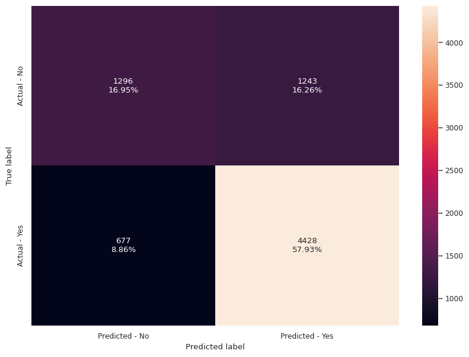

```python
make_confusion_matrix(xgb_tuned, X_test_red, y_test)
```

All the fighting with the category variables was worth it! This is the best model yet. I think another way I could have done this is used my original data dataframe - the data before I manually encoded. Then I could have removed the same columns as from the reduced data set and that might have been more intuitive/faster.

Lets see how the stacking goes -

### Stacking Classifier

```python
estimators = [
    ("AdaBoost", ab_classifier),  #classifier outperfomed tuned
    ("Gradient Boosting", gb_classifier),
    ("Random Forest", rf_tuned),
]

final_estimator = xgb_tuned
```

```python
stacking = StackingClassifier(estimators=estimators, final_estimator=final_estimator,cv=5)
stacking.fit(X_train_red,y_train_red)
```

```
StackingClassifier(cv=5,
                   estimators=[('AdaBoost', AdaBoostClassifier(random_state=1)),
                               ('Gradient Boosting',
                                GradientBoostingClassifier(random_state=1)),
                               ('Random Forest',
                                RandomForestClassifier(max_depth=5,
                                                       n_estimators=80,
                                                       oob_score=True,
                                                       random_state=1))],
                   final_estimator=XGBClassifier(base_score=None, booster=None,
                                                 callbacks=None,
                                                 colsample_bylevel=0.9,
                                                 colsam...
                                                 feature_types=None, gamma=3,
                                                 grow_policy=None,
                                                 importance_type=None,
                                                 interaction_constraints=None,
                                                 learning_rate=0.1,
                                                 max_bin=None,
                                                 max_cat_threshold=None,
                                                 max_cat_to_onehot=None,
                                                 max_delta_step=None,
                                                 max_depth=None,
                                                 max_leaves=None,
                                                 min_child_weight=None,
                                                 missing=nan,
                                                 monotone_constraints=None,
                                                 multi_strategy=None,
                                                 n_estimators=150, n_jobs=None,
                                                 num_parallel_tree=None,
                                                 random_state=1, ...))
```

```python
stacking_train = model_performance_classification_sklearn(stacking, X_train_red, y_train_red)
stacking_test = model_performance_classification_sklearn(stacking, X_test_red, y_test_red)
print("Training performance \n",stacking_train)
print("Testing performance \n",stacking_test)
```

```
Training performance
    Accuracy  Recall  Precision      F1
0   0.75454 0.87232    0.78436 0.82601
Testing performance
    Accuracy  Recall  Precision      F1
0   0.74555 0.86954    0.77632 0.82029
```

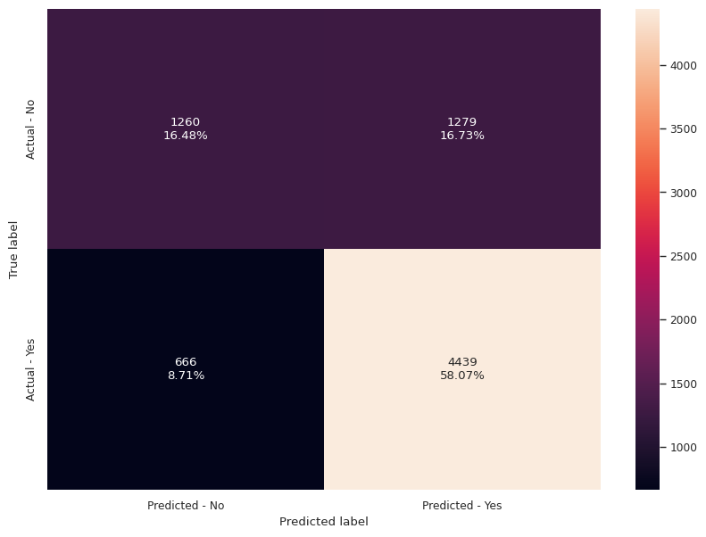

```python
make_confusion_matrix(stacking, X_test_red, y_test_red)
```

## Model Performance Comparison and Conclusions

```python
# training performance comparison

# Create a data frame with summary of model performance on training data set
all_models_perf_train = pd.concat(
    [
        dtree_red_train.T,
        dtree_red_tuned_train.T,
        bagging_estimator_train.T,
        bagging_tuned_train.T,
        rf_estimator_train.T,
        rf_tuned_train.T,
        ab_classifier_train.T,
        abc_tuned_train.T,
        gb_classifier_train.T,
        gbc_tuned_train.T,
        xgb_classifier_train.T,
        xgb_tuned_train.T,
        stacking_train.T,
    ],
    axis=1,
)
all_models_perf_train.columns = [
    "Decision Tree",
    "Tuned Decision Tree",
    "Bagging Classifier",
    "Tuned Bagging Classifier",
    "Random Forest",
    "Tuned Random Forest",
    "Adaboost Classifier",
    "Tuned Adaboost Classifier",
    "Gradient Boost Classifier",
    "Tuned Gradient Boost Classifier",
    "XGBoost Classifier",
    "XGBoost Classifier Tuned",
    "Stacking Classifier",
]
print("Training performance comparison:")
all_models_perf_train
```

```
Training performance comparison:
```

|  | Decision Tree | Tuned Decision Tree | Bagging Classifier | Tuned Bagging Classifier | Random Forest | Tuned Random Forest | Adaboost Classifier | Tuned Adaboost Classifier | Gradient Boost Classifier | Tuned Gradient Boost Classifier | XGBoost Classifier | XGBoost Classifier Tuned | Stacking Classifier |
| --- | --- | --- | --- | --- | --- | --- | --- | --- | --- | --- | --- | --- | --- |
| Accuracy | 1.00000 | 0.72954 | 0.97230 | 0.93765 | 0.99978 | 0.73268 | 0.73755 | 0.73682 | 0.75449 | 0.73739 | 0.79115 | 0.75561 | 0.75454 |
| Recall | 1.00000 | 0.91094 | 0.97356 | 0.99496 | 0.99992 | 0.92991 | 0.88517 | 0.88492 | 0.87333 | 0.91320 | 0.89230 | 0.87056 | 0.87232 |
| Precision | 1.00000 | 0.74252 | 0.98480 | 0.91848 | 0.99975 | 0.73799 | 0.76093 | 0.76033 | 0.78379 | 0.74878 | 0.81319 | 0.78640 | 0.78436 |
| F1 | 1.00000 | 0.81815 | 0.97915 | 0.95519 | 0.99983 | 0.82291 | 0.81836 | 0.81791 | 0.82614 | 0.82286 | 0.85091 | 0.82634 | 0.82601 |

Many models struggled with overfitting on the train data prior to tuning.

```python
# test performance comparison

# Create a data frame with summary of model performance on training data set
all_models_perf_test = pd.concat(
    [
        dtree_red_test.T,
        dtree_red_tuned_test.T,
        bagging_estimator_test.T,
        bagging_tuned_test.T,
        rf_estimator_test.T,
        rf_tuned_test.T,
        ab_classifier_test.T,
        abc_tuned_test.T,
        gb_classifier_test.T,
        gbc_tuned_test.T,
        xgb_classifier_test.T,
        xgb_tuned_test.T,
        stacking_test.T,
    ],
    axis=1,
)
all_models_perf_test.columns = [
    "Decision Tree",
    "Tuned Decision Tree",
    "Bagging Classifier",
    "Tuned Bagging Classifier",
    "Random Forest",
    "Tuned Random Forest",
    "Adaboost Classifier",
    "Tuned Adaboost Classifier",
    "Gradient Boost Classifier",
    "Tuned Gradient Boost Classifier",
    "XGBoost Classifier",
    "XGBoost Classifier Tuned",
    "Stacking Classifier",
]
print("Test performance comparison:")
all_models_perf_test
```

```
Test performance comparison:
```

|  | Decision Tree | Tuned Decision Tree | Bagging Classifier | Tuned Bagging Classifier | Random Forest | Tuned Random Forest | Adaboost Classifier | Tuned Adaboost Classifier | Gradient Boost Classifier | Tuned Gradient Boost Classifier | XGBoost Classifier | XGBoost Classifier Tuned | Stacking Classifier |
| --- | --- | --- | --- | --- | --- | --- | --- | --- | --- | --- | --- | --- | --- |
| Accuracy | 0.65084 | 0.72331 | 0.66837 | 0.71206 | 0.66313 | 0.72423 | 0.73509 | 0.73469 | 0.74516 | 0.72894 | 0.72894 | 0.74882 | 0.74555 |
| Recall | 0.73928 | 0.91126 | 0.75083 | 0.88110 | 0.75436 | 0.93164 | 0.88423 | 0.88482 | 0.86993 | 0.91185 | 0.84936 | 0.86738 | 0.86954 |
| Precision | 0.73826 | 0.73678 | 0.75216 | 0.73835 | 0.74459 | 0.73001 | 0.75891 | 0.75827 | 0.77572 | 0.74160 | 0.76893 | 0.78081 | 0.77632 |
| F1 | 0.73877 | 0.81478 | 0.75149 | 0.80343 | 0.74944 | 0.81859 | 0.81679 | 0.81667 | 0.82013 | 0.81796 | 0.80715 | 0.82183 | 0.82029 |

The strongest model is the one with the highest F1 on the test data - the XGBoost Tuned Model (0.82183). The other top models were the Stacking Classifier (0.82029) and the Gradient Boost Classifier (0.82013).

### Final Model(s)

For the analystical or production use case, the XGBoost Tuned Model has the highest F1. Lets look at those metrics again:

```python
xgb_tuned_train = model_performance_classification_sklearn(xgb_tuned, X_train_red_encoded, y_train_red)
xgb_tuned_test = model_performance_classification_sklearn(xgb_tuned, X_test_red, y_test_red)
print("Training performance \n",xgb_tuned_train)
print("Testing performance \n",xgb_tuned_test)
```

```
Training performance
    Accuracy  Recall  Precision      F1
0   0.75561 0.87056    0.78640 0.82634
Testing performance
    Accuracy  Recall  Precision      F1
0   0.74882 0.86738    0.78081 0.82183
```

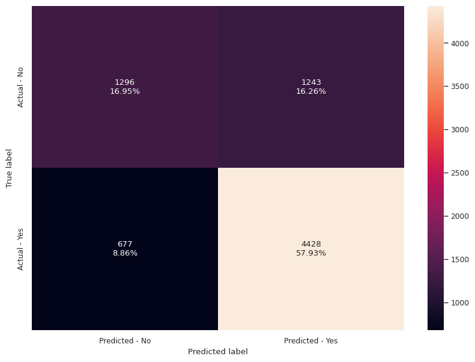

```python
make_confusion_matrix(xgb_tuned, X_test_red, y_test)
```

This model has an F1 of 0.82183 - meaning there is a decent balance between Precision (measure of correctness of positive predictions) and Recall (measure of ability to correctly predict positive true labels). The model is nearly twice as good at avoiding false negatives than it is at avoiding false positives.

However, for an average day to day triage decision makeing, the first decision tree is certainly a simpler model with barly a reduction of F1.

Taking a little time with a graphic designer (or otherwise not Python) could really make this a tool in every team huddle. Lets take a look at that tree again.

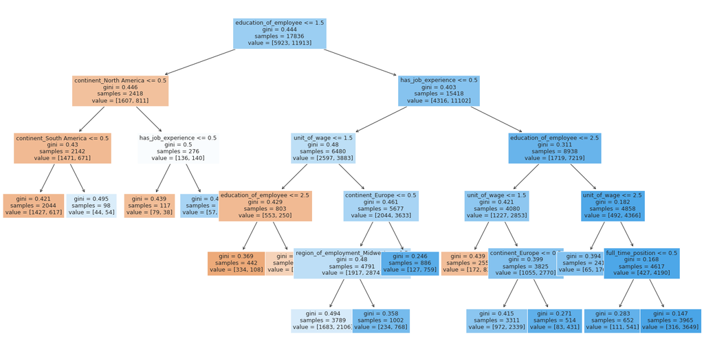

```python
plt.figure(figsize=(20, 10))
out = tree.plot_tree(
    dtree_tuned,
    feature_names=feature_names,
    filled=True,
    fontsize=9,
    node_ids=False,
    class_names=None,
)
plt.show()
```

Quickly cleaning this up visually would make a strong tool for decision makers as they traige incoming applications. There are two observations worth pointing out:

1. The one orange block on the right side of the tree reveals a pattern (or possibly a bias?) in the system - that box represents applicants with a Bachelors Degree and Job Experience, but is applying for an hourly wage. The system has the lowest rates of certification for Hourly regardless of any other feature. This observation could raise questions about potential biases in the system related to wage types and certification outcomes.
2. The tree has several levels that interact with both Education Level and Job Experience; a candidate who has both is a strong certification indicator.

## Actionable Insights and Recommendations

> **Areas for Further Study**
- There seemed to be two useful data types not available in this data set: the sector of industry that the job would be in, and the relative level of the role (entry level, mid-career, senior, executive). Given that there were many features that held little preictive power, I wonder if there are patterns still to be found.
- Another point of interest to me is the marital status of applicants.

> **Faciliation of Via Approvals**

Here are a few suggestions for streamlining the process as applications continue to increase:

- False Positives are more likely using this model than False Negatives. While denying a company and a applicant the opportunity to work in the USA, the performance metric that determins OFLC funding is the concept of "getting Americans back to work". In employing the model - the False Positives are the greater priority because there are more of them to find.
- Allowing staff members to become their own subject matter experts may increase the efficiecy. For example,
  - A team could specialize in hourly applications from appliations with work experience and education to see if the denial rate is legitamate or a bias of the system.
  - Another team could specialize in working with the higher degree (Masters, Doctorate) holders of Africa and likely the Middle East (since I would guess they were included either in Europe or Asia depending on geography).
  - A hypothesis I have is that their could also be industry based specialists, or fresh graduates of bachelors programs specialists.

> **Profile of Certification**

Candidates that have at least three of the following:

- Education of at least a Bachelor's
- Has Job Experience
- Job is Full time or Annual Salary
- From either Europe or Asia

  This can be essentially a coversheet or rubric for incoming application; if they have 3 or 4 of the above bullets they are lower risk false positives.

> **Profiles of Denial**

Candidats that have at least 3 of the following:

# Appendix

### Univariate Analysis

We could treat these outliers as defined by greater than Q3 + 1.5IQR, but all of these values are likely legitamate. Because we are going to build many models in this work, including some that are highly resiliant with regards to outliers - we will not cut off the data at any point or otherwise remove data points.

#### Observations on continent

```
Skipping outlier analysis for continent as it contains string values.
```

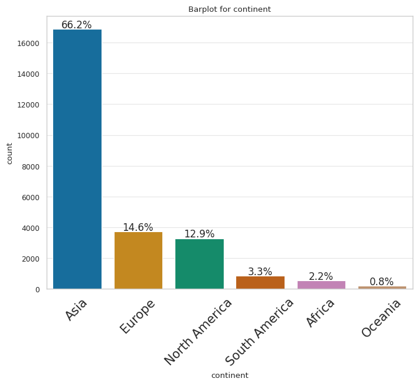

```python
labeled_barplot(data, "continent", perc=True, rotation = 45)
```

#### Observations on education of employee

```
Skipping outlier analysis for education_of_employee as it contains string values.
```

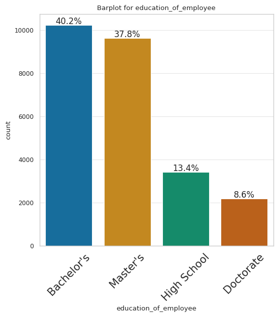

```python
labeled_barplot(data, "education_of_employee",  perc=True, rotation = 45)
```

#### Observations on job experience

```
Skipping outlier analysis for has_job_experience as it contains string values.
```

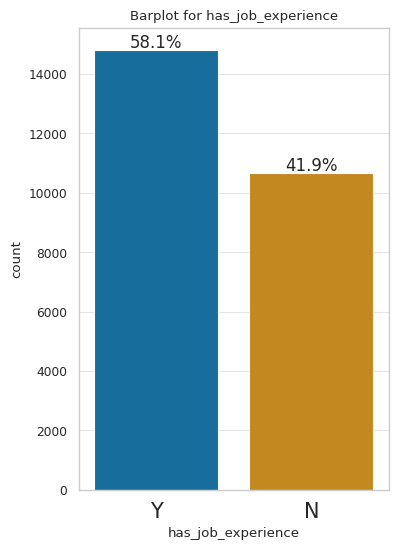

```python
labeled_barplot(data, "has_job_experience",  perc=True, rotation = 0)
```

#### Observations on job training

```
Skipping outlier analysis for requires_job_training as it contains string values.
```

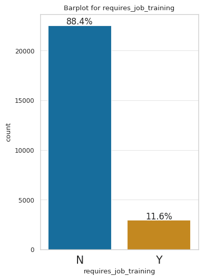

```python
labeled_barplot(data, "requires_job_training",  perc=True, rotation = 0)
```

#### Observations on number of employees

```
no_of_employees Outliers Information:

 IQR             Q3              Upper Bound     Max             #rows > Upper Bound
2482.00000      3504.00000      7227.00000      602069          1556

Unique Values Above Upper Bound: ['7242' '7261' '7262' '7285' '7290' '7320' '...etc']
```

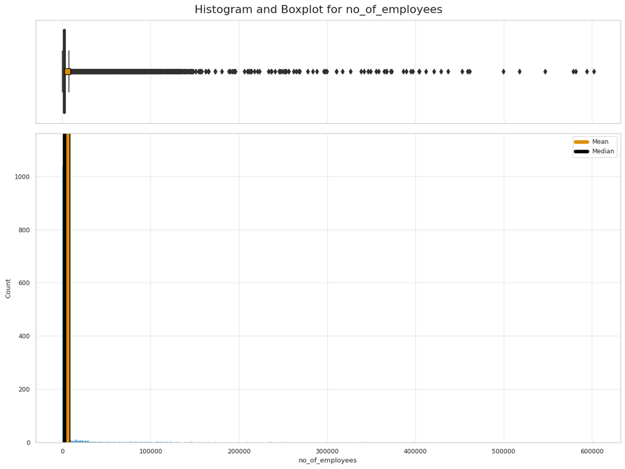

```python
histogram_boxplot(data, "no_of_employees")
```

#### Observations on years of establishment

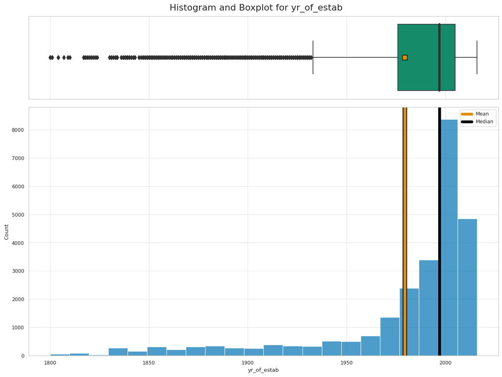

```python
histogram_boxplot(data, "yr_of_estab", bins =22)
```